# APIM - Control - Final Models

Pascal Küng, MSc, Patrick Höhener, MSc, James M. Allen, PhD, Robert Tobias, PhD, Urte Scholz, PhD

2024-11-23

```r
knitr::opts_chunk$set(echo = TRUE)

cmdstanr::set_cmdstan_path(path = "C:/Users/kueng/.cmdstan/cmdstan-2.35.0")

library(tidyverse)
library(R.utils)
library(wbCorr)
library(readxl)
library(kableExtra)
library(brms)
library(bayesplot)
library(see)
library(beepr)
library(DHARMa)
library(digest)



source(file.path('Functions', 'ReportModels.R'))
source(file.path('Functions', 'PrettyTables.R'))
source(file.path('Functions', 'ReportMeasures.R'))
source(file.path('Functions', 'PrepareData.R'))

report_function_hash <- digest::digest(summarize_brms)
```

```r
system("shutdown /a")
```

```
## [1] 1116
```

```r
# Set options for analysis
use_mi = FALSE
shutdown = FALSE
report_ordinal = FALSE
report_hurdle = TRUE
do_priorsense = FALSE

options(
  dplyr.print_max = 100,
  brms.backend = 'cmdstan',
  brms.file_refit = ifelse(use_mi, 'never', 'on_change'),
  brms.file_refit = 'on_change',
  #brms.file_refit = 'always',
  error = function() {
    beepr::beep(sound = 5)
    if (shutdown) {
      system("shutdown /s /t 180")
      quit(save = "no", status = 1)
    }
  }
  , es.use_symbols = TRUE
)


####################### Model parameters #######################

iterations = 12000 # 10'000 per chain to achieve 40'000
warmup = 2000

# NO AR!!!
#corstr = 'ar'
#corstr = 'cosy_couple'
#corstr = 'cosy_couple:user'


################################################################

suffix = as.character(iterations)
```

```r
df <- openxlsx::read.xlsx(file.path('long.xlsx'))
df_original <- df

df_double <- prepare_data(df, recode_pushing = TRUE, use_mi = use_mi)[[1]]
```

Constructing scales Re-coding pusing reshaping data (4field) centering data within and between

```r
summary(df_double$pushing)
```

Min. 1st Qu. Median Mean 3rd Qu. Max. NA’s 0.0000 0.0000 0.0000 0.1635 0.0000 5.0000 241

# Modelling

```r
# For indistinguishable Dyads
model_rows_fixed <- c(
    'Intercept',
    # '-- WITHIN PERSON MAIN EFFECTS --',
    'persuasion_self_cw',
    'persuasion_partner_cw',
    'pressure_self_cw',
    'pressure_partner_cw',
    'pushing_self_cw',
    'pushing_partner_cw',
    'day',
    'weartime_self_cw',

    # '-- BETWEEN PERSON MAIN EFFECTS',
    'persuasion_self_cb',
    'persuasion_partner_cb',
    'pressure_self_cb',
    'pressure_partner_cb',
    'pushing_self_cb',
    'pushing_partner_cb',
    'weartime_self_cb'
  )


model_rows_fixed_ordinal <- c(
  model_rows_fixed[1],
  'Intercept[1]',
  'Intercept[2]',
  'Intercept[3]',
  'Intercept[4]',
  'Intercept[5]',
  model_rows_fixed[2:length(model_rows_fixed)]
)

model_rows_random <- c(
  # '--------------',
  # '-- RANDOM EFFECTS --',
  'sd(Intercept)',
  'sd(persuasion_self_cw)',
  'sd(persuasion_partner_cw)',
  'sd(pressure_self_cw)',
  'sd(pressure_partner_cw)',
  'sd(pushing_self_cw)',
  'sd(pushing_partner_cw)',
  # '-- CORRELATION STRUCTURE -- ',
  'sigma'
)

model_rows_random_ordinal <- c(model_rows_random,'disc')
```

```r
# For indistinguishable Dyads
model_rownames_fixed <- c(
    "Intercept",
    # "-- WITHIN PERSON MAIN EFFECTS --",
    "Daily persuasion experienced",
    "Daily persuasion utilized (partner's view)", # OR partner received
    "Daily pressure experienced",
    "Daily pressure utilized (partner's view)",
    "Daily pushing experienced",
    "Daily pushing utilized (partner's view)",
    "Day",
    "Daily weartime",

    # "-- BETWEEN PERSON MAIN EFFECTS",
    "Mean persuasion experienced",
    "Mean persuasion utilized (partner's view)",
    "Mean pressure experienced",
    "Mean pressure utilized (partner's view)",
    "Mean pushing experienced",
    "Mean pushing utilized (partner's view)",
    "Mean weartime"
  )


model_rownames_fixed_ordinal <- c(
  model_rownames_fixed[1],
  'Intercept[1]',
  'Intercept[2]',
  'Intercept[3]',
  'Intercept[4]',
  'Intercept[5]',
  model_rownames_fixed[2:length(model_rownames_fixed)]
)

model_rownames_random <- c(
  # '--------------',
  # '-- RANDOM EFFECTS --',
  'sd(Intercept)',
  "sd(Daily persuasion experienced)",
  "sd(Daily persuasion utilized (partner's view))", # OR partner received
  "sd(Daily pressure experienced)",
  "sd(Daily pressure utilized (partner's view))",
  "sd(Daily pushing experienced)",
  "sd(Daily pushing utilized (partner's view))",
  # '-- CORRELATION STRUCTURE -- ',
  'sigma'
)

model_rownames_random_ordinal <- c(model_rownames_random,'disc')
```

```r
rows_to_pack <- list(
  "Within-Person Effects" = c(2,9),
  "Between-Person Effects" = c(10,16),
  "Random Effects" = c(17, 23),
  "Additional Parameters" = c(24,24)
  )


rows_to_pack_ordinal <- list(
  "Intercepts" = c(1,6),
  "Within-Person Effects" = c(2+5,9+5),
  "Between-Person Effects" = c(10+5,16+5),
  "Random Effects" = c(17+5, 23+5),
  "Additional Parameters" = c(24+5,24+6)
  )
```

HURDLE MODELS

```r
# For indistinguishable Dyads
model_rows_fixed_hu <- c(
    'Intercept',
    'hu_Intercept',
    # '-- WITHIN PERSON MAIN EFFECTS --',
    'persuasion_self_cw',
    'persuasion_partner_cw',
    'pressure_self_cw',
    'pressure_partner_cw',
    'pushing_self_cw',
    'pushing_partner_cw',
    'day',
    'weartime_self_cw',

    # '-- BETWEEN PERSON MAIN EFFECTS',
    'persuasion_self_cb',
    'persuasion_partner_cb',
    'pressure_self_cb',
    'pressure_partner_cb',
    'pushing_self_cb',
    'pushing_partner_cb',
    'weartime_self_cb',

    # HURDLE MODEL
    # '-- WITHIN PERSON MAIN EFFECTS --',
    'hu_persuasion_self_cw',
    'hu_persuasion_partner_cw',
    'hu_pressure_self_cw',
    'hu_pressure_partner_cw',
    'hu_pushing_self_cw',
    'hu_pushing_partner_cw',
    'hu_day',
    'hu_weartime_self_cw',

    # '-- BETWEEN PERSON MAIN EFFECTS',
    'hu_persuasion_self_cb',
    'hu_persuasion_partner_cb',
    'hu_pressure_self_cb',
    'hu_pressure_partner_cb',
    'hu_pushing_self_cb',
    'hu_pushing_partner_cb',
    'hu_weartime_self_cb'
  )

model_rows_fixed_hu_ordinal <- c(
  model_rows_fixed_hu[1:2],
  'Intercept[1]',
  'Intercept[2]',
  'Intercept[3]',
  'Intercept[4]',
  'Intercept[5]',
  model_rows_fixed_hu[3:length(model_rows_fixed_hu)]
)


model_rows_random_hu <- c(
  # '--------------',
  # '-- RANDOM EFFECTS --',
  'sd(Intercept)',
  'sd(hu_Intercept)',
  'sd(persuasion_self_cw)',
  'sd(persuasion_partner_cw)',
  'sd(pressure_self_cw)',
  'sd(pressure_partner_cw)',
  'sd(pushing_self_cw)',
  'sd(pushing_partner_cw)',
  # HURDLE
  'sd(hu_persuasion_self_cw)',
  'sd(hu_persuasion_partner_cw)',
  'sd(hu_pressure_self_cw)',
  'sd(hu_pressure_partner_cw)',
  'sd(hu_pushing_self_cw)',
  'sd(hu_pushing_partner_cw)',
  # '-- CORRELATION STRUCTURE -- ',
  'sigma'
)

model_rows_random_hu_ordinal <- c(model_rows_random_hu,'disc')
```

```r
# For indistinguishable Dyads
model_rownames_fixed_hu <- c(
    "Intercept",
    "Hurdle Intercept",
    # "-- WITHIN PERSON MAIN EFFECTS --",
    "Daily persuasion experienced",
    "Daily persuasion utilized (partner's view)", # OR partner received
    "Daily pressure experienced",
    "Daily pressure utilized (partner's view)",
    "Daily pushing experienced",
    "Daily pushing utilized (partner's view)",
    "Day",
    "Daily weartime",

    # "-- BETWEEN PERSON MAIN EFFECTS",
    "Mean persuasion experienced",
    "Mean persuasion utilized (partner's view)",
    "Mean pressure experienced",
    "Mean pressure utilized (partner's view)",
    "Mean pushing experienced",
    "Mean pushing utilized (partner's view)",
    "Mean weartime",

    # HURDLE
    # "-- WITHIN PERSON MAIN EFFECTS --",
    "Hu Daily persuasion experienced",
    "Hu Daily persuasion utilized (partner's view)", # OR partner received
    "Hu Daily pressure experienced",
    "Hu Daily pressure utilized (partner's view)",
    "Hu Daily pushing experienced",
    "Hu Daily pushing utilized (partner's view)",
    "Hu Day",
    "Hu Daily weartime",

    # "-- BETWEEN PERSON MAIN EFFECTS",
    "Hu Mean persuasion experienced",
    "Hu Mean persuasion utilized (partner's view)",
    "Hu Mean pressure experienced",
    "Hu Mean pressure utilized (partner's view)",
    "Hu Mean pushing experienced",
    "Hu Mean pushing utilized (partner's view)",
    "Hu Mean weartime"
  )



model_rownames_fixed_hu_ordinal <- c(
  model_rownames_fixed_hu[1:2],
  'Intercept[1]',
  'Intercept[2]',
  'Intercept[3]',
  'Intercept[4]',
  'Intercept[5]',
  model_rownames_fixed_hu[3:length(model_rownames_fixed_hu)]
)



model_rownames_random_hu <- c(
  # '--------------',
  # '-- RANDOM EFFECTS --',
  'sd(Intercept)',
  'sd(Hurdle Intercept)',
  "sd(Daily persuasion experienced)",
  "sd(Daily persuasion utilized (partner's view))", # OR partner received
  "sd(Daily pressure experienced)",
  "sd(Daily pressure utilized (partner's view))",
  "sd(Daily pushing experienced)",
  "sd(Daily pushing utilized (partner's view))",

  # Hurdle
  "sd(Hu Daily persuasion experienced)",
  "sd(Hu Daily persuasion utilized (partner's view))", # OR partner received
  "sd(Hu Daily pressure experienced)",
  "sd(Hu Daily pressure utilized (partner's view))",
  "sd(Hu Daily pushing experienced)",
  "sd(Hu Daily pushing utilized (partner's view))",
  # '-- CORRELATION STRUCTURE -- ',
  'sigma'
)

model_rownames_random_hu_ordinal <- c(model_rownames_random_hu,'disc')
```

```r
rows_to_pack_hu <- list(
  "Conditional Within-Person Effects" = c(3,10),
  "Conditional Between-Person Effects" = c(11,17),

  "Hurdle Within-Person Effects" = c(18,25),
  "Hurdle Between-Person Effects" = c(26,32),

  "Random Effects" = c(33, 46),
  "Additional Parameters" = c(47,47)
  )

rows_to_pack_hu_ordinal <- list(
  "Intercepts" = c(1,7),
  "Conditional Within-Person Effects" = c(3+5,10+5),
  "Conditional Between-Person Effects" = c(11+5,17+5),

  "Hurdle Within-Person Effects" = c(18+5,25+5),
  "Hurdle Between-Person Effects" = c(26+5,32+5),

  "Random Effects" = c(33+5, 46+5),
  "Additional Parameters" = c(47+5,47+6)
  )
```

## Self-Reported MVPA

```r
range(df_double$pa_sub, na.rm = T)
```

```
## [1]   0 720
```

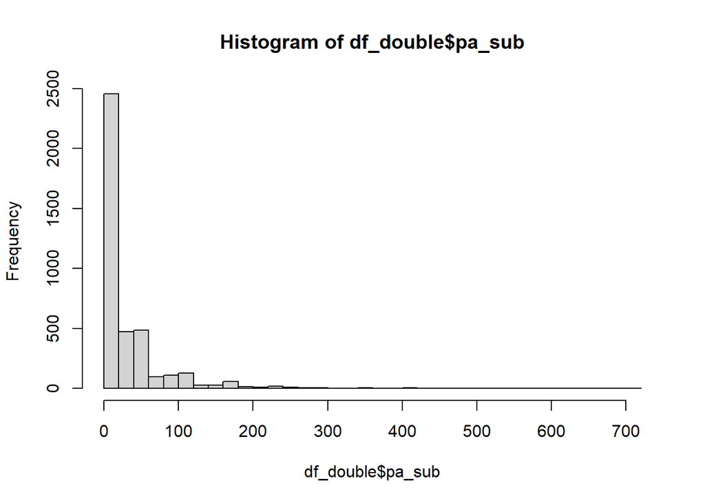

```r
hist(df_double$pa_sub, breaks = 40)
```

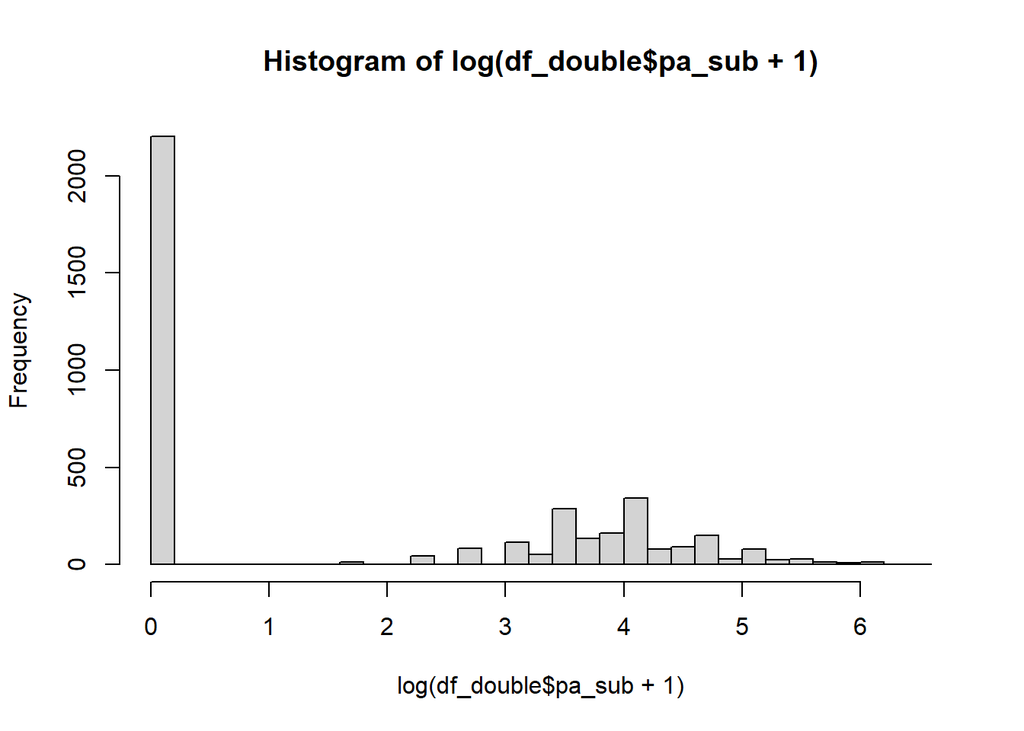

```r
hist(log(df_double$pa_sub+00000000001), breaks = 40)
```

### Hurdle Lognormal Model

```r
formula <- bf(
  pa_sub ~
    persuasion_self_cw + persuasion_partner_cw +
    pressure_self_cw + pressure_partner_cw +
    pushing_self_cw + pushing_partner_cw +

    persuasion_self_cb + persuasion_partner_cb +
    pressure_self_cb + pressure_partner_cb +
    pushing_self_cb + pushing_partner_cb +

    day +

    # Random effects
    (1 + persuasion_self_cw + persuasion_partner_cw +
    pressure_self_cw + pressure_partner_cw +
    pushing_self_cw + pushing_partner_cw | coupleID),

  hu = ~ persuasion_self_cw + persuasion_partner_cw +
    pressure_self_cw + pressure_partner_cw +
    pushing_self_cw + pushing_partner_cw +

    persuasion_self_cb + persuasion_partner_cb +
    pressure_self_cb + pressure_partner_cb +
    pushing_self_cb + pushing_partner_cb +

    day +

    # Random effects
    (1 + persuasion_self_cw + persuasion_partner_cw +
    pressure_self_cw + pressure_partner_cw +
    pushing_self_cw + pushing_partner_cw | coupleID)
  #, autocor = autocor_str
)

prior1 <- c(
  brms::set_prior("normal(0, 2.5)", class = "b")
  , brms::set_prior("normal(0, 2)", class = "b", dpar = "hu")
  , brms::set_prior("normal(0, 50)", class = "Intercept") # for non-zero PA
  , brms::set_prior("normal(0.5, 2.5)", class = "Intercept", dpar = 'hu') # hurdle part
  , brms::set_prior("normal(0, 2)", class = "sd", group = "coupleID", lb = 0)
  , brms::set_prior("student_t(3, 0, 2.5)", class = "sigma", lb = 0)
)

#brms::validate_prior(
#  prior1,
#  formula = formula,
#  data = df_double,
#  family = hurdle_lognormal()
#)

#df_minimal <- df_double[, c("AorB", all.vars(as.formula(formula)))]

pa_sub <- my_brm(
  mi = use_mi,
  imputed_data = implist,

  formula = formula,
  prior = prior1,
  data = df_double,
  family = brms::hurdle_lognormal(),
  #family = brms::hurdle_negbinomial(),
  #family = brms::hurdle_poisson(),
  #control = list(adapt_delta = 0.95, max_treedepth = 15),
  iter = iterations,
  warmup = warmup,
  chains = 4,
  cores = 4,
  seed = 42,
  file = file.path("models_cache_brms", paste0("pa_sub_hu_lognormal_NOAR", suffix))
  #, file_refit = 'always'
)
pa_sub_digest <- digest::digest(pa_sub)
```

```r
check_brms(pa_sub, log_pp_check = TRUE)
```

```
##
## Divergences:
```

```
## 0 of 40000 iterations ended with a divergence.
```

```
##
## Tree depth:
```

```
## 0 of 40000 iterations saturated the maximum tree depth of 10.
```

```
##
## Energy:
```

```
## E-BFMI indicated no pathological behavior.
```

[figure not shown]

```
## Using 10 posterior draws for ppc type 'ecdf_overlay' by default.
```

[figure not shown]

```
## Using 10 posterior draws for ppc type 'dens_overlay' by default.
```

[figure not shown]

```
##
## Computed from 40000 by 3736 log-likelihood matrix.
##
##          Estimate    SE
## elpd_loo -10490.4 166.4
## p_loo       181.3   6.2
## looic     20980.8 332.8
## ------
## MCSE of elpd_loo is 0.1.
## MCSE and ESS estimates assume MCMC draws (r_eff in [0.5, 2.0]).
##
## All Pareto k estimates are good (k < 0.7).
## See help('pareto-k-diagnostic') for details.
```

```r
DHARMa.check_brms.all(pa_sub, integer = TRUE, outliers_type = 'bootstrap')
```

[figure not shown]

```
##
##  DHARMa bootstrapped outlier test
##
## data:  model.check
## outliers at both margin(s) = 7, observations = 3736, p-value = 0.8
## alternative hypothesis: two.sided
##  percent confidence interval:
##  0.0005353319 0.0032119914
## sample estimates:
## outlier frequency (expected: 0.00166220556745182 )
##                                        0.001873662
```

```r
if (do_priorsense) {
  priorsense_vars <- c(
      'Intercept',
      'b_persuasion_self_cw',
      'b_persuasion_partner_cw',
      'b_pressure_self_cw',
      'b_pressure_partner_cw',
      'b_pushing_self_cw',
      'b_pushing_partner_cw'
  )

  hurdle_priorsense_vars <- c(
    'Intercept_hu',
    'b_hu_persuasion_self_cw',
    'b_hu_persuasion_partner_cw',
    'b_hu_pressure_self_cw',
    'b_hu_pressure_partner_cw',
    'b_hu_pushing_self_cw',
    'b_hu_pushing_partner_cw'
  )

  gc()
  priorsense::powerscale_sensitivity(pa_sub, variable = c(priorsense_vars, hurdle_priorsense_vars))
  priorsense::powerscale_plot_dens(pa_sub, variable = c(priorsense_vars, hurdle_priorsense_vars))
  priorsense::powerscale_plot_ecdf(pa_sub, variable = c(priorsense_vars, hurdle_priorsense_vars))
  priorsense::powerscale_plot_quantities(pa_sub, variable = c(priorsense_vars, hurdle_priorsense_vars))
}
```

```r
# summarize with rope range for hurdle part
summary_pa_sub_hurdle <- summarize_brms(
  pa_sub,
  stats_to_report = c('pd','ROPE'),
  rope_range = c(-0.18, 0.18),
  model_rows_fixed = model_rows_fixed_hu,
  model_rows_random = model_rows_random_hu,
  model_rownames_fixed = model_rownames_fixed_hu,
  model_rownames_random = model_rownames_random_hu,
  exponentiate = T)
# rope range for continuous part of the model
rope_factor <- sd(log(pa_sub$data$pa_sub[pa_sub$data$pa_sub > 0]))
rope_range_continuous = c(-0.1 * rope_factor, 0.1 * rope_factor)

summary_pa_sub_continuous <- summarize_brms(
  pa_sub,
  rope_range = rope_range_continuous,
  model_rows_fixed = model_rows_fixed_hu,
  model_rows_random = model_rows_random_hu,
  model_rownames_fixed = model_rownames_fixed_hu,
  model_rownames_random = model_rownames_random_hu,
  exponentiate = T)
```

```
## Sampling priors, please wait...
```

```r
# Replace only the ROPE and % in Rope columns for rows with 'Hu'
summary_pa_sub <- summary_pa_sub_continuous

columns_to_replace <- c("ROPE", "inside ROPE")

summary_pa_sub[grepl('Hu', rownames(summary_pa_sub)), columns_to_replace] <-
  summary_pa_sub_hurdle[grepl('Hu', rownames(summary_pa_sub_hurdle)), columns_to_replace]

# Print the updated dataframe
summary_pa_sub %>%
  print_df(rows_to_pack = rows_to_pack_hu)
```

|  | exp(Est.) | SE | 95% CI | pd | ROPE | inside ROPE | BF | BF_Evidence | Rhat | Bulk_ESS | Tail_ESS |
| --- | --- | --- | --- | --- | --- | --- | --- | --- | --- | --- | --- |
| Intercept | 47.95*** | 3.03 | [42.23, 54.34] | 1.000 | [0.92, 1.08] | 0.000 | >100 | Overwhelming Evidence | 1.001 | 7325 | 14978 |
| Hurdle Intercept | 0.85 | 0.14 | [ 0.61, 1.18] | 0.838 | [0.84, 1.20] | 0.515 | 0.099 | Strong Evidence for Null | 1.000 | 4644 | 10721 |
| **Conditional Within-Person Effects** |  |  |  |  |  |  |  |  |  |  |  |
| Daily persuasion experienced | 1.03 | 0.03 | [ 0.97, 1.08] | 0.832 | [0.92, 1.08] | 0.969 | 0.017 | Very Strong Evidence for Null | 1.000 | 11179 | 19513 |
| Daily persuasion utilized (partner’s view) | 1.03 | 0.02 | [ 0.98, 1.08] | 0.902 | [0.92, 1.08] | 0.976 | 0.023 | Very Strong Evidence for Null | 1.000 | 16280 | 22705 |
| Daily pressure experienced | 0.89* | 0.04 | [ 0.80, 0.98] | 0.987 | [0.92, 1.08] | 0.215 | 0.281 | Moderate Evidence for Null | 1.000 | 25549 | 25127 |
| Daily pressure utilized (partner’s view) | 0.94 | 0.04 | [ 0.86, 1.03] | 0.917 | [0.92, 1.08] | 0.650 | 0.045 | Strong Evidence for Null | 1.000 | 27538 | 22984 |
| Daily pushing experienced | 1.03 | 0.04 | [ 0.96, 1.10] | 0.769 | [0.92, 1.08] | 0.933 | 0.019 | Very Strong Evidence for Null | 1.000 | 22879 | 25906 |
| Daily pushing utilized (partner’s view) | 0.99 | 0.03 | [ 0.93, 1.05] | 0.637 | [0.92, 1.08] | 0.978 | 0.013 | Very Strong Evidence for Null | 1.000 | 22162 | 25742 |
| Day | 1.01 | 0.06 | [ 0.89, 1.14] | 0.549 | [0.92, 1.08] | 0.789 | 0.025 | Very Strong Evidence for Null | 1.000 | 39583 | 31325 |
| Daily weartime | NA | NA | NA | NA | NA | NA | NA | NA | NA | NA | NA |
| **Conditional Between-Person Effects** |  |  |  |  |  |  |  |  |  |  |  |
| Mean persuasion experienced | 1.01 | 0.16 | [ 0.74, 1.39] | 0.534 | [0.92, 1.08] | 0.384 | 0.063 | Strong Evidence for Null | 1.000 | 5679 | 11615 |
| Mean persuasion utilized (partner’s view) | 0.98 | 0.15 | [ 0.72, 1.35] | 0.539 | [0.92, 1.08] | 0.384 | 0.064 | Strong Evidence for Null | 1.001 | 5613 | 11737 |
| Mean pressure experienced | 1.14 | 0.21 | [ 0.80, 1.64] | 0.765 | [0.92, 1.08] | 0.263 | 0.093 | Strong Evidence for Null | 1.001 | 8538 | 16974 |
| Mean pressure utilized (partner’s view) | 0.88 | 0.17 | [ 0.61, 1.29] | 0.745 | [0.92, 1.08] | 0.261 | 0.094 | Strong Evidence for Null | 1.000 | 8892 | 17039 |
| Mean pushing experienced | 1.33 | 0.31 | [ 0.84, 2.09] | 0.886 | [0.92, 1.08] | 0.128 | 0.195 | Moderate Evidence for Null | 1.001 | 8468 | 16152 |
| Mean pushing utilized (partner’s view) | 1.40 | 0.33 | [ 0.88, 2.24] | 0.923 | [0.92, 1.08] | 0.094 | 0.265 | Moderate Evidence for Null | 1.001 | 7823 | 16081 |
| Mean weartime | NA | NA | NA | NA | NA | NA | NA | NA | NA | NA | NA |
| **Hurdle Within-Person Effects** |  |  |  |  |  |  |  |  |  |  |  |
| Hu Daily persuasion experienced | 1.53*** | 0.10 | [ 1.36, 1.75] | 1.000 | [0.84, 1.20] | 0.000 | >100 | Overwhelming Evidence | 1.000 | 18293 | 23098 |
| Hu Daily persuasion utilized (partner’s view) | 1.32*** | 0.08 | [ 1.19, 1.50] | 1.000 | [0.84, 1.20] | 0.038 | >100 | Overwhelming Evidence | 1.000 | 21760 | 23402 |
| Hu Daily pressure experienced | 0.82 | 0.13 | [ 0.58, 1.13] | 0.897 | [0.84, 1.20] | 0.431 | 0.183 | Moderate Evidence for Null | 1.000 | 23948 | 22959 |
| Hu Daily pressure utilized (partner’s view) | 1.47* | 0.27 | [ 1.05, 2.32] | 0.988 | [0.84, 1.20] | 0.115 | 1.184 | Weak Evidence | 1.000 | 22679 | 16886 |
| Hu Daily pushing experienced | 1.71*** | 0.28 | [ 1.27, 2.46] | 1.000 | [0.84, 1.20] | 0.009 | 25.585 | Strong Evidence | 1.000 | 18260 | 21188 |
| Hu Daily pushing utilized (partner’s view) | 1.83*** | 0.23 | [ 1.46, 2.44] | 1.000 | [0.84, 1.20] | 0.000 | >100 | Overwhelming Evidence | 1.000 | 21693 | 23686 |
| Hu Day | 0.92 | 0.12 | [ 0.71, 1.19] | 0.743 | [0.84, 1.20] | 0.739 | 0.081 | Strong Evidence for Null | 1.000 | 42026 | 30353 |
| Hu Daily weartime | NA | NA | NA | NA | NA | NA | NA | NA | NA | NA | NA |
| **Hurdle Between-Person Effects** |  |  |  |  |  |  |  |  |  |  |  |
| Hu Mean persuasion experienced | 1.19 | 0.46 | [ 0.54, 2.60] | 0.673 | [0.84, 1.20] | 0.321 | 0.217 | Moderate Evidence for Null | 1.001 | 4572 | 9486 |
| Hu Mean persuasion utilized (partner’s view) | 1.18 | 0.46 | [ 0.53, 2.56] | 0.667 | [0.84, 1.20] | 0.327 | 0.213 | Moderate Evidence for Null | 1.001 | 4614 | 9826 |
| Hu Mean pressure experienced | 0.31** | 0.13 | [ 0.13, 0.74] | 0.996 | [0.84, 1.20] | 0.011 | 7.828 | Moderate Evidence | 1.000 | 7034 | 15087 |
| Hu Mean pressure utilized (partner’s view) | 0.57 | 0.25 | [ 0.24, 1.36] | 0.902 | [0.84, 1.20] | 0.143 | 0.504 | Weak Evidence for Null | 1.000 | 7037 | 15000 |
| Hu Mean pushing experienced | 2.70 | 1.53 | [ 0.87, 8.16] | 0.958 | [0.84, 1.20] | 0.056 | 1.372 | Weak Evidence | 1.000 | 7198 | 13867 |
| Hu Mean pushing utilized (partner’s view) | 2.79 | 1.57 | [ 0.89, 8.46] | 0.962 | [0.84, 1.20] | 0.051 | 1.415 | Weak Evidence | 1.000 | 6943 | 12974 |
| Hu Mean weartime | NA | NA | NA | NA | NA | NA | NA | NA | NA | NA | NA |
| **Random Effects** |  |  |  |  |  |  |  |  |  |  |  |
| sd(Intercept) | 0.32 | 0.04 | [0.24, 0.42] | NA | NA | NA | NA | NA | 1.000 | 8803 | 15643 |
| sd(Hurdle Intercept) | 0.89 | 0.12 | [0.69, 1.18] | NA | NA | NA | NA | NA | 1.000 | 7673 | 14307 |
| sd(Daily persuasion experienced) | 0.12 | 0.02 | [0.08, 0.17] | NA | NA | NA | NA | NA | 1.000 | 16113 | 24856 |
| sd(Daily persuasion utilized (partner’s view)) | 0.09 | 0.02 | [0.05, 0.13] | NA | NA | NA | NA | NA | 1.000 | 19267 | 21079 |
| sd(Daily pressure experienced) | 0.07 | 0.06 | [0.00, 0.24] | NA | NA | NA | NA | NA | 1.001 | 12569 | 14433 |
| sd(Daily pressure utilized (partner’s view)) | 0.06 | 0.05 | [0.00, 0.18] | NA | NA | NA | NA | NA | 1.000 | 15590 | 14458 |
| sd(Daily pushing experienced) | 0.11 | 0.04 | [0.04, 0.19] | NA | NA | NA | NA | NA | 1.000 | 11320 | 7606 |
| sd(Daily pushing utilized (partner’s view)) | 0.09 | 0.03 | [0.02, 0.17] | NA | NA | NA | NA | NA | 1.000 | 10989 | 6835 |
| sd(Hu Daily persuasion experienced) | 0.18 | 0.08 | [0.02, 0.34] | NA | NA | NA | NA | NA | 1.000 | 8938 | 6082 |
| sd(Hu Daily persuasion utilized (partner’s view)) | 0.17 | 0.08 | [0.02, 0.33] | NA | NA | NA | NA | NA | 1.000 | 9475 | 7735 |
| sd(Hu Daily pressure experienced) | 0.25 | 0.21 | [0.01, 0.85] | NA | NA | NA | NA | NA | 1.001 | 11940 | 15619 |
| sd(Hu Daily pressure utilized (partner’s view)) | 0.28 | 0.25 | [0.01, 1.00] | NA | NA | NA | NA | NA | 1.000 | 10937 | 15282 |
| sd(Hu Daily pushing experienced) | 0.62 | 0.18 | [0.32, 1.08] | NA | NA | NA | NA | NA | 1.000 | 15379 | 20817 |
| sd(Hu Daily pushing utilized (partner’s view)) | 0.31 | 0.15 | [0.04, 0.64] | NA | NA | NA | NA | NA | 1.000 | 10681 | 7340 |
| **Additional Parameters** |  |  |  |  |  |  |  |  |  |  |  |
| sigma | 0.68 | 0.01 | [0.66, 0.71] | NA | NA | NA | NA | NA | 1.000 | 38393 | 29400 |

```r
# Plot continuous part of model

variable <- c(
  '(Intercept)',
  'b_persuasion_self_cw',
  'b_persuasion_partner_cw',
  'b_pressure_self_cw',
  'b_pressure_partner_cw',
  'b_pushing_self_cw',
  'b_pushing_partner_cw'
)


plot(
  bayestestR::p_direction(pa_sub, parameter = variable),
  priors = TRUE
) + theme_bw()
```

[figure not shown]

```r
plot(
  bayestestR::rope(
    pa_sub,
    parameter = variable,
    range = rope_range_continuous,
    verbose = F,
    ci = 1
  )
) + theme_bw()
```

[figure not shown]

```r
# Hurdle part of the model
variable <- c(
  'b_hu_persuasion_self_cw',
  'b_hu_persuasion_partner_cw',
  'b_hu_pressure_self_cw',
  'b_hu_pressure_partner_cw',
  'b_hu_pushing_self_cw',
  'b_hu_pushing_partner_cw'
)

plot(
  bayestestR::p_direction(pa_sub, parameter = variable),
  priors = TRUE
) + theme_bw()
```

[figure not shown]

```r
# The rope range for the bernoulli part of the model is -0.18, 0.18
plot(
  bayestestR::rope(pa_sub, parameter = variable, range = c(-0.18, 0.18), ci = 1),
  verbose = FALSE
) + theme_bw()
```

```
## Possible multicollinearity between b_persuasion_partner_cb and
##   b_persuasion_self_cb (r = 0.77), b_hu_persuasion_partner_cb and
##   b_hu_persuasion_self_cb (r = 0.83). This might lead to inappropriate
##   results. See 'Details' in '?rope'.
```

[figure not shown]

```r
conds_eff <- conditional_spaghetti(
  pa_sub,
  effects = c(
    'persuasion_self_cw',
    'persuasion_partner_cw',
    'pressure_self_cw',
    'pressure_partner_cw',
    'pushing_self_cw',
    'pushing_partner_cw'
  ),
  x_label = c(
    'Received Persuasion',
    'Exerted Persuasion',
    'Received Pressure',
    'Exerted Pressure',
    'Received Plan-Related Pushing',
    'Exerted Plan-Related Pushing'
  ),
  group_var = 'coupleID',
  plot_full_range = TRUE,
  y_limits = c(0, 100),
  y_label = "Same-Day MVPA",
  y_labels = c('Probability of Being Active', 'Minutes of MVPA When Active', 'Overall Expected Minutes of MVPA'),
  , filter_quantiles = .9995
  , font_family = 'Candara'
)
print(conds_eff)
```

$persuasion_self_cw

[figure not shown]

$persuasion_partner_cw

[figure not shown]

$pressure_self_cw

[figure not shown]

$pressure_partner_cw

[figure not shown]

$pushing_self_cw

[figure not shown]

$pushing_partner_cw

[figure not shown]

**Note.** This graphic illustrates the relationship between social control and moderate to vigorous physical activity (MVPA) using a Bayesian Hurdle-Lognormal Multilevel Model. The predictor is centered within individuals to examine how deviations from their average social control relate to same-day MVPA. Shaded areas indicate credible intervals, thick lines show fixed effects, and thin lines represent random effects, highlighting variability across couples. The plots display the probability of being active, expected minutes of MVPA when active, and combined predicted MVPA. The bottom density plot visualizes the posterior distributions of slope estimates, transformed to represent multiplicative changes in odds ratios (hurdle component) or expected values. Medians and 95% credible intervals (2.5th and 97.5th percentiles) are shown. Effects are significant, when the 95% credible interval does not overlap 1.

```r
x_label = c(
    'Received Persuasion',
    'Exerted Persuasion',
    'Received Pressure',
    'Exerted Pressure',
    'Received Plan-Related Pushing',
    'Exerted Plan-Related Pushing'
  )

for (i in 1:length(conds_eff)) {
  effname <- names(conds_eff)[i]
  eff_plot <- conds_eff[[i]]
  x_label_i <- x_label[[i]]
  rmarkdown::render(
    "C:/Users/kueng/DataAnalysis/02TimeAndTiesControl/Output/Plots/BeautifulPlotWithNote.Rmd",
    output_file = paste0('C:/Users/kueng/DataAnalysis/02TimeAndTiesControl/Output/Plots/Graphic_', effname, '.pdf'),
    params = list(
      p_i = eff_plot,
      p_name = effname,
      x_label = x_label_i
      ),
    envir = new.env(),
    quiet = TRUE
  )
}
```

```r
marginaleffects::avg_predictions(pa_sub)
```

```
##
##  Estimate 2.5 % 97.5 %
##      30.9  29.4   32.5
##
## Type:  response
## Columns: estimate, conf.low, conf.high
```

## Device Based MVPA

```r
range(df_double$pa_obj, na.rm = T)
```

```
## [1]   5.75 971.25
```

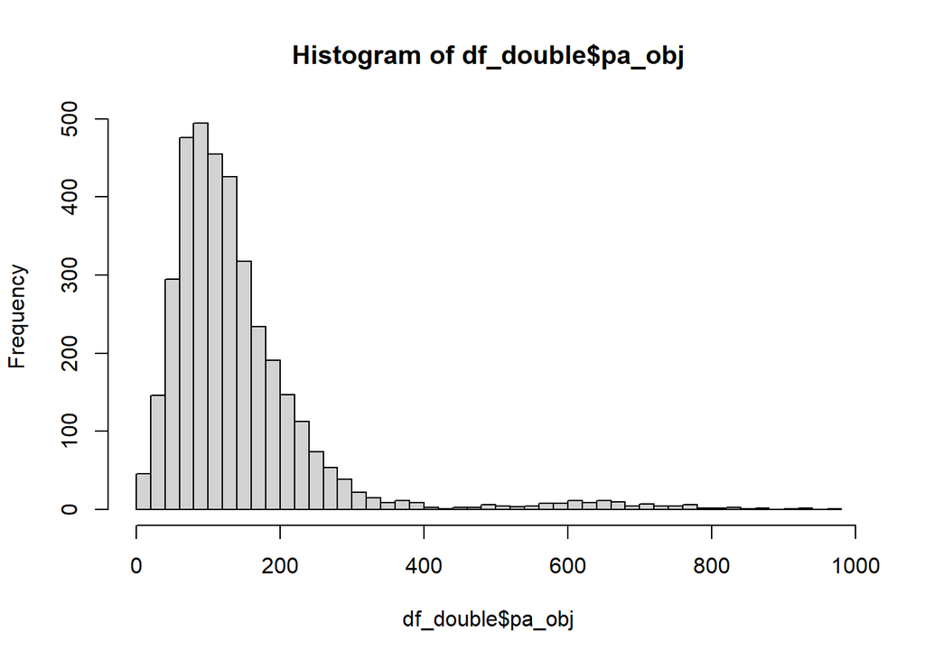

```r
hist(df_double$pa_obj, breaks = 50)
```

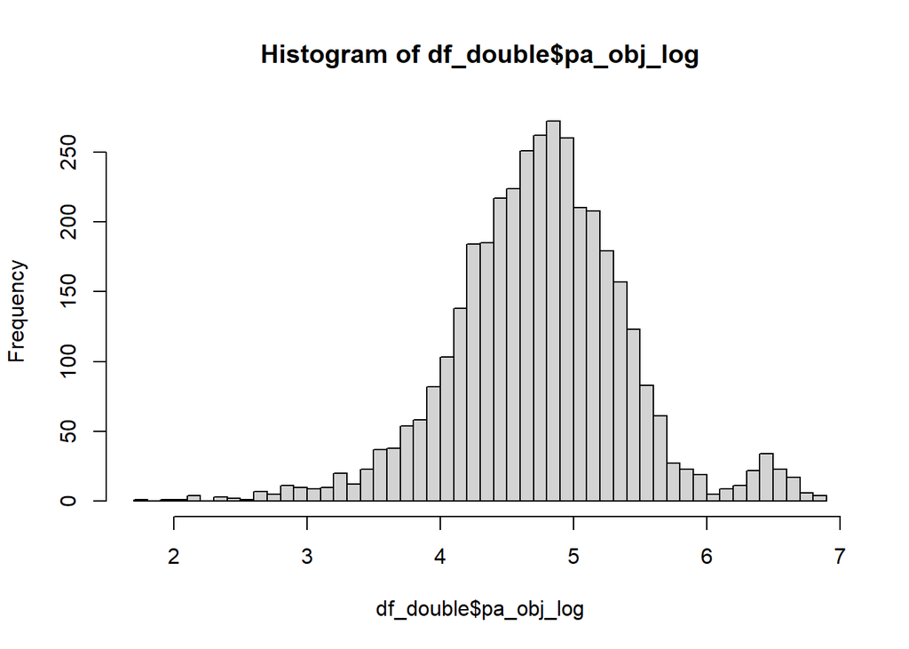

```r
df_double$pa_obj_log <- log(df_double$pa_obj)

hist(df_double$pa_obj_log, breaks = 50)
```

### Lognormal Model

```r
formula <- bf(
  pa_obj ~
    persuasion_self_cw + persuasion_partner_cw +
    pressure_self_cw + pressure_partner_cw +
    pushing_self_cw + pushing_partner_cw +

    persuasion_self_cb + persuasion_partner_cb +
    pressure_self_cb + pressure_partner_cb +
    pushing_self_cb + pushing_partner_cb +

    day + weartime_self_cw + weartime_self_cb +

    # Random effects
    (persuasion_self_cw + persuasion_partner_cw +
    pressure_self_cw + pressure_partner_cw +
    pushing_self_cw + pushing_partner_cw | coupleID)
  #, autocor = autocor_str
)



prior1 <- c(
  brms::set_prior("normal(0, 2.5)", class = "b")
  , brms::set_prior("normal(0, 50)", class = "Intercept")
  , brms::set_prior("normal(0, 2)", class = "sd", group = "coupleID", lb = 0)
  , brms::set_prior("student_t(3, 0, 2.5)", class = "sigma", lb = 0)
)


#brms::validate_prior(
#  prior1,
#  formula = formula,
#  data = df_double,
#  family = lognormal()
#  )

#df_minimal <- df_double[, c("AorB", all.vars(as.formula(formula)))]

pa_obj_log <- my_brm(
  mi = use_mi,
  imputed_data = implist,

  formula = formula,
  prior = prior1,
  data = df_double,
  family = lognormal(),
  #control = list(adapt_delta = 0.95),
  iter = iterations,
  warmup = warmup,
  chains = 4,
  cores = 4,
  seed = 7777,
  file = file.path("models_cache_brms", paste0("pa_obj_log_gaussian_NOAR", suffix))
)
pa_obj_log_digest <- digest::digest(pa_obj_log)
```

```r
check_brms(pa_obj_log, log_pp_check = TRUE)
```

```
##
## Divergences:
```

```
## 0 of 40000 iterations ended with a divergence.
```

```
##
## Tree depth:
```

```
## 0 of 40000 iterations saturated the maximum tree depth of 10.
```

```
##
## Energy:
```

```
## E-BFMI indicated no pathological behavior.
```

[figure not shown]

```
## Using 10 posterior draws for ppc type 'ecdf_overlay' by default.
```

[figure not shown]

```
## Using 10 posterior draws for ppc type 'dens_overlay' by default.
```

[figure not shown]

```
##
## Computed from 40000 by 3337 log-likelihood matrix.
##
##          Estimate    SE
## elpd_loo -18781.8  68.4
## p_loo        92.1   4.5
## looic     37563.7 136.8
## ------
## MCSE of elpd_loo is 0.1.
## MCSE and ESS estimates assume MCMC draws (r_eff in [0.4, 2.3]).
##
## All Pareto k estimates are good (k < 0.7).
## See help('pareto-k-diagnostic') for details.
```

```r
DHARMa.check_brms.all(pa_obj_log, integer = TRUE, outliers_type = 'bootstrap')
```

```
## DHARMa:testOutliers with type = binomial may have inflated Type I error rates for integer-valued distributions. To get a more exact result, it is recommended to re-run testOutliers with type = 'bootstrap'. See ?testOutliers for details
```

[figure not shown]

```
##
##  DHARMa bootstrapped outlier test
##
## data:  model.check
## outliers at both margin(s) = 24, observations = 3337, p-value < 2.2e-16
## alternative hypothesis: two.sided
##  percent confidence interval:
##  0.001341025 0.004652382
## sample estimates:
## outlier frequency (expected: 0.00287383877734492 )
##                                        0.007192089
```

```r
if (do_priorsense) {
  gc()
  priorsense::powerscale_sensitivity(pa_obj_log, variable = priorsense_vars)
  priorsense::powerscale_plot_dens(pa_obj_log, variable = priorsense_vars)
  priorsense::powerscale_plot_ecdf(pa_obj_log, variable = priorsense_vars)
  priorsense::powerscale_plot_quantities(pa_obj_log, variable = priorsense_vars)
}
```

```r
# rope range for lognormal model
rope_factor <- sd(log(pa_obj_log$data$pa_obj))
rope_range_log = c(-0.1 * rope_factor, 0.1 * rope_factor)

summarize_brms(
  pa_obj_log,
  rope_range = rope_range_log,
  model_rows_fixed = model_rows_fixed,
  model_rows_random = model_rows_random,
  model_rownames_fixed = model_rownames_fixed,
  model_rownames_random = model_rownames_random,
  exponentiate = T) %>%
  print_df(rows_to_pack = rows_to_pack)
```

```
## Sampling priors, please wait...
```

|  | exp(Est.) | SE | 95% CI | pd | ROPE | inside ROPE | BF | BF_Evidence | Rhat | Bulk_ESS | Tail_ESS |
| --- | --- | --- | --- | --- | --- | --- | --- | --- | --- | --- | --- |
| Intercept | 117.27*** | 6.24 | [105.41, 130.66] | 1.000 | [0.94, 1.07] | 0.000 | >100 | Overwhelming Evidence | 1.000 | 5582 | 10902 |
| **Within-Person Effects** |  |  |  |  |  |  |  |  |  |  |  |
| Daily persuasion experienced | 1.03 | 0.02 | [ 1.00, 1.06] | 0.965 | [0.94, 1.07] | 0.990 | 0.033 | Strong Evidence for Null | 1.000 | 22787 | 26727 |
| Daily persuasion utilized (partner’s view) | 1.02 | 0.02 | [ 0.99, 1.05] | 0.888 | [0.94, 1.07] | 0.997 | 0.014 | Very Strong Evidence for Null | 1.000 | 28722 | 29910 |
| Daily pressure experienced | 0.94 | 0.03 | [ 0.88, 1.01] | 0.960 | [0.94, 1.07] | 0.547 | 0.066 | Strong Evidence for Null | 1.000 | 41819 | 28808 |
| Daily pressure utilized (partner’s view) | 0.98 | 0.03 | [ 0.92, 1.05] | 0.717 | [0.94, 1.07] | 0.905 | 0.016 | Very Strong Evidence for Null | 1.000 | 46892 | 31087 |
| Daily pushing experienced | 1.03 | 0.03 | [ 0.98, 1.08] | 0.900 | [0.94, 1.07] | 0.907 | 0.025 | Very Strong Evidence for Null | 1.000 | 32795 | 27546 |
| Daily pushing utilized (partner’s view) | 1.02 | 0.02 | [ 0.97, 1.06] | 0.774 | [0.94, 1.07] | 0.986 | 0.011 | Very Strong Evidence for Null | 1.000 | 46123 | 31056 |
| Day | 0.97 | 0.03 | [ 0.91, 1.04] | 0.784 | [0.94, 1.07] | 0.849 | 0.019 | Very Strong Evidence for Null | 1.000 | 63974 | 30299 |
| Daily weartime | 1.00*** | 0.00 | [ 1.00, 1.00] | 1.000 | [0.94, 1.07] | 1.000 | 0.106 | Moderate Evidence for Null | 1.000 | 41200 | 26262 |
| **Between-Person Effects** |  |  |  |  |  |  |  |  |  |  |  |
| Mean persuasion experienced | 1.10 | 0.16 | [ 0.83, 1.47] | 0.756 | [0.94, 1.07] | 0.275 | 0.074 | Strong Evidence for Null | 1.001 | 5262 | 10215 |
| Mean persuasion utilized (partner’s view) | 0.98 | 0.14 | [ 0.73, 1.31] | 0.550 | [0.94, 1.07] | 0.349 | 0.057 | Strong Evidence for Null | 1.001 | 5260 | 10280 |
| Mean pressure experienced | 0.98 | 0.14 | [ 0.73, 1.31] | 0.564 | [0.94, 1.07] | 0.339 | 0.059 | Strong Evidence for Null | 1.001 | 7201 | 14024 |
| Mean pressure utilized (partner’s view) | 0.96 | 0.14 | [ 0.72, 1.28] | 0.602 | [0.94, 1.07] | 0.339 | 0.059 | Strong Evidence for Null | 1.001 | 6726 | 13627 |
| Mean pushing experienced | 0.97 | 0.20 | [ 0.64, 1.47] | 0.561 | [0.94, 1.07] | 0.242 | 0.083 | Strong Evidence for Null | 1.000 | 7856 | 13134 |
| Mean pushing utilized (partner’s view) | 1.24 | 0.25 | [ 0.83, 1.88] | 0.859 | [0.94, 1.07] | 0.141 | 0.147 | Moderate Evidence for Null | 1.000 | 7770 | 12879 |
| Mean weartime | 1.00 | 0.00 | [ 1.00, 1.00] | 0.912 | [0.94, 1.07] | 1.000 | 0.000 | Very Strong Evidence for Null | 1.000 | 50538 | 35353 |
| **Random Effects** |  |  |  |  |  |  |  |  |  |  |  |
| sd(Intercept) | 0.30 | 0.04 | [0.24, 0.40] | NA | NA | NA | NA | NA | 1.000 | 7902 | 14886 |
| sd(Daily persuasion experienced) | 0.05 | 0.01 | [0.02, 0.08] | NA | NA | NA | NA | NA | 1.000 | 20801 | 17210 |
| sd(Daily persuasion utilized (partner’s view)) | 0.06 | 0.02 | [0.03, 0.09] | NA | NA | NA | NA | NA | 1.000 | 20659 | 19450 |
| sd(Daily pressure experienced) | 0.04 | 0.03 | [0.00, 0.13] | NA | NA | NA | NA | NA | 1.000 | 17044 | 16600 |
| sd(Daily pressure utilized (partner’s view)) | 0.04 | 0.03 | [0.00, 0.11] | NA | NA | NA | NA | NA | 1.000 | 23038 | 19677 |
| sd(Daily pushing experienced) | 0.08 | 0.04 | [0.01, 0.15] | NA | NA | NA | NA | NA | 1.000 | 8952 | 10098 |
| sd(Daily pushing utilized (partner’s view)) | 0.04 | 0.03 | [0.00, 0.10] | NA | NA | NA | NA | NA | 1.000 | 13943 | 18163 |
| **Additional Parameters** |  |  |  |  |  |  |  |  |  |  |  |
| sigma | 0.57 | 0.01 | [0.56, 0.59] | NA | NA | NA | NA | NA | 1.000 | 60296 | 29184 |

```r
plot(
  bayestestR::p_direction(pa_obj_log),
  priors = TRUE
) +
  coord_cartesian(xlim = c(-3, 3)) +
  theme_bw()
```

[figure not shown]

```r
plot(
  bayestestR::rope(pa_obj_log, range = rope_range_log, ci = 1)
) + theme_bw()
```

```
## Possible multicollinearity between b_persuasion_partner_cb and
##   b_persuasion_self_cb (r = 0.89), b_pressure_self_cb and
##   b_persuasion_self_cb (r = 0.74), b_pressure_partner_cb and
##   b_persuasion_self_cb (r = 0.74), b_pressure_self_cb and
##   b_persuasion_partner_cb (r = 0.72), b_pressure_partner_cb and
##   b_persuasion_partner_cb (r = 0.78), b_pushing_partner_cb and
##   b_pushing_self_cb (r = 0.83). This might lead to inappropriate results.
##   See 'Details' in '?rope'.
```

[figure not shown]

```r
# Nothing significant, no plots
```

## Affect

```r
range(df_double$aff, na.rm = T)
```

```
## [1] 0 5
```

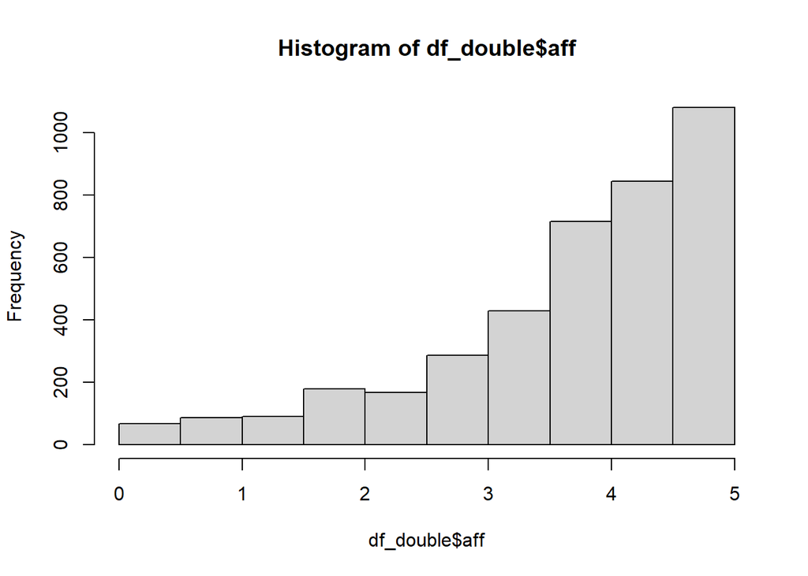

```r
hist(df_double$aff, breaks = 15)
```

### Gaussian

```r
formula <- bf(
  aff ~
    persuasion_self_cw + persuasion_partner_cw +
    pressure_self_cw + pressure_partner_cw +
    pushing_self_cw + pushing_partner_cw +

    persuasion_self_cb + persuasion_partner_cb +
    pressure_self_cb + pressure_partner_cb +
    pushing_self_cb + pushing_partner_cb +

    day +

    # Random effects
    (persuasion_self_cw + persuasion_partner_cw +
    pressure_self_cw + pressure_partner_cw +
    pushing_self_cw + pushing_partner_cw | coupleID)
  #, autocor = autocor_str
)


prior1 <- c(
  brms::set_prior("normal(0, 5)", class = "b")
  ,brms::set_prior("normal(0, 20)", class = "Intercept", lb=1, ub=6)
  , brms::set_prior("normal(0, 2)", class = "sd", group = "coupleID", lb = 0)
  , brms::set_prior("student_t(3, 0, 2.5)", class = "sigma", lb = 0)
)

#brms::validate_prior(
#  prior1,
#  formula = formula,
#  data = df_double,
#  family = gaussian()
#  )

#df_minimal <- df_double[, c("AorB", all.vars(as.formula(formula)))]

mood_gauss <- my_brm(
  mi = use_mi,
  imputed_data = implist,

  formula = formula,
  prior = prior1,
  data = df_double,
  family = gaussian(),
  #control = list(adapt_delta = 0.95, max_treedepth = 15),
  iter = iterations,
  warmup = warmup,
  chains = 4,
  cores = 4,
  seed = 7777,
  file = file.path("models_cache_brms", paste0("mood_gauss_NOAR", suffix))
)
mood_gauss_digest <- digest::digest(mood_gauss)
```

```r
check_brms(mood_gauss, log_pp_check = FALSE)
```

```
##
## Divergences:
```

```
## 0 of 40000 iterations ended with a divergence.
```

```
##
## Tree depth:
```

```
## 0 of 40000 iterations saturated the maximum tree depth of 10.
```

```
##
## Energy:
```

```
## E-BFMI indicated no pathological behavior.
```

[figure not shown]

```
## Using 10 posterior draws for ppc type 'ecdf_overlay' by default.
```

[figure not shown]

```
## Using 10 posterior draws for ppc type 'dens_overlay' by default.
```

[figure not shown]

```
##
## Computed from 40000 by 3736 log-likelihood matrix.
##
##          Estimate    SE
## elpd_loo  -5186.2  59.2
## p_loo        75.4   3.3
## looic     10372.5 118.4
## ------
## MCSE of elpd_loo is NA.
## MCSE and ESS estimates assume MCMC draws (r_eff in [0.5, 2.2]).
##
## Pareto k diagnostic values:
##                          Count Pct.    Min. ESS
## (-Inf, 0.7]   (good)     3735  100.0%  5780
##    (0.7, 1]   (bad)         1    0.0%  <NA>
##    (1, Inf)   (very bad)    0    0.0%  <NA>
## See help('pareto-k-diagnostic') for details.
```

```r
DHARMa.check_brms.all(mood_gauss, integer = FALSE)
```

[figure not shown]

```
##
##  DHARMa outlier test based on exact binomial test with approximate
##  expectations
##
## data:  model.check
## outliers at both margin(s) = 27, observations = 3736, p-value =
## 2.533e-08
## alternative hypothesis: true probability of success is not equal to 0.001998002
## 95 percent confidence interval:
##  0.004767871 0.010497581
## sample estimates:
## frequency of outliers (expected: 0.001998001998002 )
##                                          0.007226981
```

```r
if (do_priorsense) {
  gc()
  priorsense::powerscale_sensitivity(mood_gauss, variable = priorsense_vars)
  priorsense::powerscale_plot_dens(mood_gauss, variable = priorsense_vars)
  priorsense::powerscale_plot_ecdf(mood_gauss, variable = priorsense_vars)
  priorsense::powerscale_plot_quantities(mood_gauss, variable = priorsense_vars)
}
```

```r
summarize_brms(
  mood_gauss,
  model_rows_fixed = model_rows_fixed,
  model_rows_random = model_rows_random,
  model_rownames_fixed = model_rownames_fixed,
  model_rownames_random = model_rownames_random,
  exponentiate = F) %>%
  print_df(rows_to_pack = rows_to_pack)
```

```
## Sampling priors, please wait...
```

|  | Est. | SE | 95% CI | pd | ROPE | inside ROPE | BF | BF_Evidence | Rhat | Bulk_ESS | Tail_ESS |
| --- | --- | --- | --- | --- | --- | --- | --- | --- | --- | --- | --- |
| Intercept | 3.70*** | 0.10 | [ 3.50, 3.91] | 1.000 | [-0.11, 0.11] | 0.000 | >100 | Overwhelming Evidence | 1.002 | 4495 | 9545 |
| **Within-Person Effects** |  |  |  |  |  |  |  |  |  |  |  |
| Daily persuasion experienced | 0.00 | 0.02 | [-0.04, 0.05] | 0.545 | [-0.11, 0.11] | 1.000 | 0.004 | Very Strong Evidence for Null | 1.000 | 35462 | 27914 |
| Daily persuasion utilized (partner’s view) | 0.02 | 0.02 | [-0.02, 0.07] | 0.828 | [-0.11, 0.11] | 1.000 | 0.007 | Very Strong Evidence for Null | 1.000 | 29416 | 30178 |
| Daily pressure experienced | -0.04 | 0.05 | [-0.15, 0.07] | 0.769 | [-0.11, 0.11] | 0.919 | 0.013 | Very Strong Evidence for Null | 1.000 | 35865 | 27332 |
| Daily pressure utilized (partner’s view) | -0.02 | 0.05 | [-0.14, 0.08] | 0.668 | [-0.11, 0.11] | 0.934 | 0.012 | Very Strong Evidence for Null | 1.000 | 33073 | 24399 |
| Daily pushing experienced | 0.02 | 0.03 | [-0.04, 0.08] | 0.758 | [-0.11, 0.11] | 0.997 | 0.008 | Very Strong Evidence for Null | 1.000 | 41974 | 29904 |
| Daily pushing utilized (partner’s view) | 0.08* | 0.03 | [ 0.01, 0.14] | 0.985 | [-0.11, 0.11] | 0.867 | 0.080 | Strong Evidence for Null | 1.000 | 31271 | 28932 |
| Day | 0.26*** | 0.06 | [ 0.15, 0.37] | 1.000 | [-0.11, 0.11] | 0.005 | >100 | Overwhelming Evidence | 1.000 | 59723 | 29576 |
| Daily weartime | NA | NA | NA | NA | NA | NA | NA | NA | NA | NA | NA |
| **Between-Person Effects** |  |  |  |  |  |  |  |  |  |  |  |
| Mean persuasion experienced | 0.35 | 0.28 | [-0.20, 0.89] | 0.893 | [-0.11, 0.11] | 0.152 | 0.123 | Moderate Evidence for Null | 1.000 | 4262 | 9105 |
| Mean persuasion utilized (partner’s view) | 0.23 | 0.28 | [-0.31, 0.78] | 0.799 | [-0.11, 0.11] | 0.227 | 0.080 | Strong Evidence for Null | 1.000 | 4267 | 8956 |
| Mean pressure experienced | -0.32 | 0.27 | [-0.86, 0.23] | 0.876 | [-0.11, 0.11] | 0.170 | 0.108 | Moderate Evidence for Null | 1.000 | 4747 | 11106 |
| Mean pressure utilized (partner’s view) | -0.32 | 0.28 | [-0.86, 0.23] | 0.877 | [-0.11, 0.11] | 0.173 | 0.110 | Moderate Evidence for Null | 1.000 | 4951 | 11430 |
| Mean pushing experienced | 0.22 | 0.38 | [-0.55, 1.01] | 0.714 | [-0.11, 0.11] | 0.200 | 0.089 | Strong Evidence for Null | 1.001 | 6400 | 11111 |
| Mean pushing utilized (partner’s view) | 0.35 | 0.38 | [-0.41, 1.14] | 0.823 | [-0.11, 0.11] | 0.156 | 0.118 | Moderate Evidence for Null | 1.001 | 6362 | 11744 |
| Mean weartime | NA | NA | NA | NA | NA | NA | NA | NA | NA | NA | NA |
| **Random Effects** |  |  |  |  |  |  |  |  |  |  |  |
| sd(Intercept) | 0.60 | 0.08 | [0.48, 0.78] | NA | NA | NA | NA | NA | 1.001 | 7483 | 13998 |
| sd(Daily persuasion experienced) | 0.04 | 0.03 | [0.00, 0.10] | NA | NA | NA | NA | NA | 1.001 | 10758 | 15861 |
| sd(Daily persuasion utilized (partner’s view)) | 0.08 | 0.03 | [0.02, 0.13] | NA | NA | NA | NA | NA | 1.000 | 11761 | 9894 |
| sd(Daily pressure experienced) | 0.07 | 0.06 | [0.00, 0.24] | NA | NA | NA | NA | NA | 1.000 | 16544 | 18107 |
| sd(Daily pressure utilized (partner’s view)) | 0.08 | 0.07 | [0.00, 0.26] | NA | NA | NA | NA | NA | 1.000 | 14798 | 17566 |
| sd(Daily pushing experienced) | 0.05 | 0.04 | [0.00, 0.14] | NA | NA | NA | NA | NA | 1.000 | 13961 | 15345 |
| sd(Daily pushing utilized (partner’s view)) | 0.07 | 0.05 | [0.00, 0.17] | NA | NA | NA | NA | NA | 1.000 | 13129 | 14428 |
| **Additional Parameters** |  |  |  |  |  |  |  |  |  |  |  |
| sigma | 0.96 | 0.01 | [0.94, 0.98] | NA | NA | NA | NA | NA | 1.000 | 63319 | 29501 |

```r
plot(
  bayestestR::p_direction(mood_gauss),
  priors = TRUE
)  +
  coord_cartesian(xlim = c(-3, 3)) +
  theme_bw()
```

[figure not shown]

```r
plot(
  bayestestR::rope(mood_gauss, ci = 1)
) + theme_bw()
```

```
## Possible multicollinearity between b_pressure_self_cb and
##   b_persuasion_self_cb (r = 0.82), b_pressure_partner_cb and
##   b_persuasion_self_cb (r = 0.8), b_pressure_self_cb and
##   b_persuasion_partner_cb (r = 0.8), b_pressure_partner_cb and
##   b_persuasion_partner_cb (r = 0.82), b_pressure_partner_cb and
##   b_pressure_self_cb (r = 0.77), b_pushing_partner_cb and
##   b_pushing_self_cb (r = 0.89). This might lead to inappropriate results.
##   See 'Details' in '?rope'.
```

[figure not shown]

```r
conditional_spaghetti(
  mood_gauss,
  effects = c('pushing_partner_cw'),
  group_var = 'coupleID',
  plot_full_range = TRUE
)
```

$pushing_partner_cw

[figure not shown]

```r
marginaleffects::avg_predictions(mood_gauss)
```

```
##
##  Estimate 2.5 % 97.5 %
##      3.82  3.79   3.85
##
## Type:  response
## Columns: estimate, conf.low, conf.high
```

## Reactance

```r
range(df_double$reactance, na.rm = T)
```

```
## [1] 0 5
```

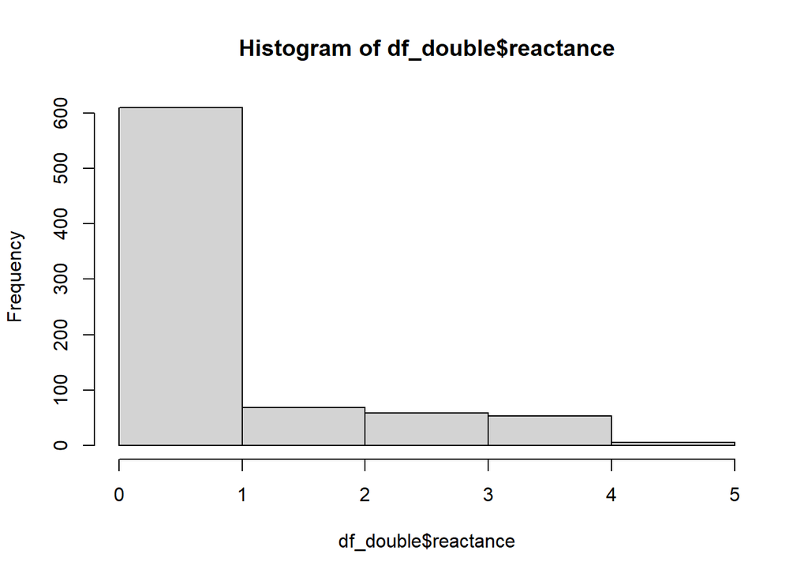

```r
hist(df_double$reactance, breaks = 7)
```

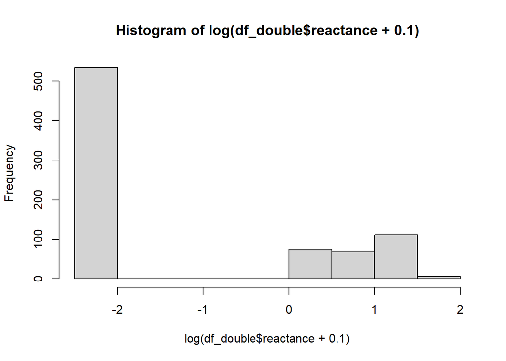

```r
hist(log(df_double$reactance+0.1), breaks = 10)
```

### Ordinal

```r
df_double$reactance_ordinal <- factor(df_double$reactance,
                                      levels = 0:5,
                                      ordered = TRUE)

formula <- bf(
  reactance_ordinal ~
    persuasion_self_cw + persuasion_partner_cw +
    pressure_self_cw + pressure_partner_cw +
    pushing_self_cw + pushing_partner_cw +

    persuasion_self_cb + persuasion_partner_cb +
    pressure_self_cb + pressure_partner_cb +
    pushing_self_cb + pushing_partner_cb +

    day +

    # Random effects
    (persuasion_self_cw + persuasion_partner_cw +
    pressure_self_cw + pressure_partner_cw +
    pushing_self_cw + pushing_partner_cw | coupleID)
  #, autocor = autocor_str
)


prior1 <- c(
  brms::set_prior("normal(0, 2.5)", class = "b")
  , brms::set_prior("normal(0, 2)", class = "sd", group = "coupleID", lb = 0)
)


#brms::validate_prior(
#  prior1,
#  formula = formula,
#  data = df_double,
#  family = cumulative() # HURDLE_CUMULATIVE
#  )


#df_minimal <- df_double[, c("AorB", all.vars(as.formula(formula)))]

reactance_ordinal <- my_brm(
  mi = use_mi,
  imputed_data = implist,

  formula = formula,
  prior = prior1,
  data = df_double,
  family = brms::cumulative(),
  #control = list(adapt_delta = 0.95),
  iter = iterations,
  warmup = warmup,
  chains = 4,
  cores = 4,
  seed = 7777
  , file = file.path("models_cache_brms", paste0("reactance_ordinal_NOARNOAR_", suffix))
)
reactance_ordinal_digest <- digest::digest(reactance_ordinal)
```

```r
check_brms(reactance_ordinal)
```

```
##
## Divergences:
```

```
## 0 of 40000 iterations ended with a divergence.
```

```
##
## Tree depth:
```

```
## 0 of 40000 iterations saturated the maximum tree depth of 10.
```

```
##
## Energy:
```

```
## E-BFMI indicated no pathological behavior.
```

[figure not shown]

```
## Using 10 posterior draws for ppc type 'ecdf_overlay' by default.
```

[figure not shown]

```
## Using 10 posterior draws for ppc type 'dens_overlay' by default.
```

[figure not shown]

```
##
## Computed from 40000 by 756 log-likelihood matrix.
##
##          Estimate   SE
## elpd_loo   -682.1 31.9
## p_loo        73.7  5.4
## looic      1364.3 63.9
## ------
## MCSE of elpd_loo is NA.
## MCSE and ESS estimates assume MCMC draws (r_eff in [0.4, 1.6]).
##
## Pareto k diagnostic values:
##                          Count Pct.    Min. ESS
## (-Inf, 0.7]   (good)     751   99.3%   903
##    (0.7, 1]   (bad)        5    0.7%   <NA>
##    (1, Inf)   (very bad)   0    0.0%   <NA>
## See help('pareto-k-diagnostic') for details.
```

```r
DHARMa.check_brms.all(reactance_ordinal, outliers_type = 'bootstrap')
```

[figure not shown]

```
##
##  DHARMa bootstrapped outlier test
##
## data:  model.check
## outliers at both margin(s) = 2, observations = 756, p-value = 0.04
## alternative hypothesis: two.sided
##  percent confidence interval:
##  0.000000000 0.001322751
## sample estimates:
## outlier frequency (expected: 0.000436507936507937 )
##                                         0.002645503
```

```r
if (do_priorsense) {
  gc()
  priorsense::powerscale_sensitivity(reactance_ordinal, variable = priorsense_vars)
  priorsense::powerscale_plot_dens(reactance_ordinal, variable = priorsense_vars)
  priorsense::powerscale_plot_ecdf(reactance_ordinal, variable = priorsense_vars)
  priorsense::powerscale_plot_quantities(reactance_ordinal, variable = priorsense_vars)
}
```

```r
summarize_brms(
  reactance_ordinal,
  rope_range = c(-0.18, 0.18),
  model_rows_fixed = model_rows_fixed_ordinal,
  model_rows_random = model_rows_random_ordinal,
  model_rownames_fixed = model_rownames_fixed_ordinal,
  model_rownames_random = model_rownames_random_ordinal,
  exponentiate = T) %>%
  print_df(rows_to_pack = rows_to_pack_ordinal)
```

```
## Sampling priors, please wait...
```

|  | OR | SE | 95% CI | pd | ROPE | inside ROPE | BF | BF_Evidence | Rhat | Bulk_ESS | Tail_ESS |
| --- | --- | --- | --- | --- | --- | --- | --- | --- | --- | --- | --- |
| **Intercepts** |  |  |  |  |  |  |  |  |  |  |  |
| Intercept | NA | NA | NA | NA | NA | NA | NA | NA | NA | NA | NA |
| Intercept[1] | 3.84*** | 0.98 | [ 2.34, 6.49] | 1.000 | [0.84, 1.20] | 0.000 | >100 | Overwhelming Evidence | 1.000 | 28792 | 29901 |
| Intercept[2] | 8.32*** | 2.24 | [ 4.96, 14.45] | 1.000 | [0.84, 1.20] | 0.000 | >100 | Overwhelming Evidence | 1.000 | 29900 | 30020 |
| Intercept[3] | 23.17*** | 6.80 | [ 13.17, 42.42] | 1.000 | [0.84, 1.20] | 0.000 | >100 | Overwhelming Evidence | 1.000 | 31532 | 31530 |
| Intercept[4] | 101.19*** | 35.37 | [ 52.40, 208.53] | 1.000 | [0.84, 1.20] | 0.000 | >100 | Overwhelming Evidence | 1.000 | 34784 | 31711 |
| Intercept[5] | 3422.14*** | 2190.68 | [1091.76, 13601.17] | 1.000 | [0.84, 1.20] | 0.000 | >100 | Overwhelming Evidence | 1.000 | 47511 | 31296 |
| **Within-Person Effects** |  |  |  |  |  |  |  |  |  |  |  |
| Daily persuasion experienced | 0.85* | 0.07 | [ 0.71, 0.99] | 0.980 | [0.84, 1.20] | 0.568 | 0.277 | Moderate Evidence for Null | 1.000 | 33454 | 27707 |
| Daily persuasion utilized (partner’s view) | 1.03 | 0.10 | [ 0.84, 1.24] | 0.604 | [0.84, 1.20] | 0.922 | 0.040 | Strong Evidence for Null | 1.000 | 30268 | 27064 |
| Daily pressure experienced | 1.86* | 0.36 | [ 1.18, 2.69] | 0.994 | [0.84, 1.20] | 0.027 | 3.012 | Moderate Evidence | 1.000 | 19636 | 23573 |
| Daily pressure utilized (partner’s view) | 1.23 | 0.29 | [ 0.70, 2.08] | 0.808 | [0.84, 1.20] | 0.385 | 0.149 | Moderate Evidence for Null | 1.000 | 25256 | 21310 |
| Daily pushing experienced | 1.16 | 0.11 | [ 0.96, 1.42] | 0.945 | [0.84, 1.20] | 0.618 | 0.136 | Moderate Evidence for Null | 1.000 | 28471 | 27169 |
| Daily pushing utilized (partner’s view) | 0.92 | 0.11 | [ 0.71, 1.17] | 0.768 | [0.84, 1.20] | 0.758 | 0.062 | Strong Evidence for Null | 1.000 | 32368 | 25496 |
| Day | 1.47 | 0.51 | [ 0.77, 2.86] | 0.872 | [0.84, 1.20] | 0.227 | 0.260 | Moderate Evidence for Null | 1.000 | 45161 | 31117 |
| Daily weartime | NA | NA | NA | NA | NA | NA | NA | NA | NA | NA | NA |
| **Between-Person Effects** |  |  |  |  |  |  |  |  |  |  |  |
| Mean persuasion experienced | 1.12 | 0.57 | [ 0.41, 3.14] | 0.591 | [0.84, 1.20] | 0.268 | 0.212 | Moderate Evidence for Null | 1.000 | 13321 | 21398 |
| Mean persuasion utilized (partner’s view) | 1.38 | 0.79 | [ 0.45, 4.35] | 0.713 | [0.84, 1.20] | 0.216 | 0.263 | Moderate Evidence for Null | 1.000 | 14141 | 21745 |
| Mean pressure experienced | 3.48* | 1.90 | [ 1.18, 10.66] | 0.988 | [0.84, 1.20] | 0.022 | 3.043 | Moderate Evidence | 1.000 | 15342 | 23058 |
| Mean pressure utilized (partner’s view) | 1.18 | 0.67 | [ 0.37, 3.58] | 0.612 | [0.84, 1.20] | 0.236 | 0.241 | Moderate Evidence for Null | 1.000 | 15692 | 22489 |
| Mean pushing experienced | 1.20 | 0.89 | [ 0.28, 5.59] | 0.599 | [0.84, 1.20] | 0.189 | 0.305 | Weak Evidence for Null | 1.000 | 18260 | 25276 |
| Mean pushing utilized (partner’s view) | 0.11* | 0.10 | [ 0.02, 0.64] | 0.993 | [0.84, 1.20] | 0.008 | 8.595 | Moderate Evidence | 1.000 | 23596 | 28667 |
| Mean weartime | NA | NA | NA | NA | NA | NA | NA | NA | NA | NA | NA |
| **Random Effects** |  |  |  |  |  |  |  |  |  |  |  |
| sd(Intercept) | 0.81 | 0.20 | [0.48, 1.26] | NA | NA | NA | NA | NA | 1.000 | 14049 | 23078 |
| sd(Daily persuasion experienced) | 0.16 | 0.12 | [0.01, 0.42] | NA | NA | NA | NA | NA | 1.000 | 7067 | 14443 |
| sd(Daily persuasion utilized (partner’s view)) | 0.21 | 0.14 | [0.01, 0.51] | NA | NA | NA | NA | NA | 1.000 | 10643 | 14404 |
| sd(Daily pressure experienced) | 0.55 | 0.25 | [0.10, 1.14] | NA | NA | NA | NA | NA | 1.001 | 9501 | 8812 |
| sd(Daily pressure utilized (partner’s view)) | 0.40 | 0.38 | [0.02, 1.55] | NA | NA | NA | NA | NA | 1.000 | 10032 | 16731 |
| sd(Daily pushing experienced) | 0.20 | 0.13 | [0.01, 0.51] | NA | NA | NA | NA | NA | 1.000 | 10833 | 13309 |
| sd(Daily pushing utilized (partner’s view)) | 0.14 | 0.13 | [0.01, 0.59] | NA | NA | NA | NA | NA | 1.000 | 15145 | 18957 |
| **Additional Parameters** |  |  |  |  |  |  |  |  |  |  |  |
| sigma | NA | NA | NA | NA | NA | NA | NA | NA | NA | NA | NA |
| disc | 1.00 | 0.00 | [1.00, 1.00] | NA | NA | NA | NA | NA | NA | NA | NA |

```r
plot(
  bayestestR::p_direction(reactance_ordinal),
  priors = TRUE
) +
  coord_cartesian(xlim = c(-6, 6)) +
  theme_bw()
```

[figure not shown]

```r
plot(
  bayestestR::rope(reactance_ordinal, range = c(-0.18, 0.18), ci = 1)
) + theme_bw()
```

```
## Possible multicollinearity between b_Intercept[4] and b_Intercept[2] (r
##   = 0.76), b_Intercept[4] and b_Intercept[3] (r = 0.83),
##   b_pressure_self_cb and b_persuasion_self_cb (r = 0.72),
##   b_pressure_partner_cb and b_persuasion_partner_cb (r = 0.79). This might
##   lead to inappropriate results. See 'Details' in '?rope'.
```

[figure not shown]

```r
conditional_spaghetti(
  reactance_ordinal,
  effects = c('persuasion_self_cw', 'pressure_self_cw')
  , group_var = 'coupleID'
  #, n_groups = 15
  , plot_full_range = T
)
```

[figure not shown]

```r
marginaleffects::avg_predictions(reactance_ordinal)
```

```
##
##  Group Estimate   2.5 % 97.5 %
##      0  0.68193 0.65457 0.7076
##      1  0.09412 0.07508 0.1157
##      2  0.08361 0.06612 0.1041
##      3  0.06984 0.05464 0.0874
##      4  0.06395 0.05130 0.0775
##      5  0.00527 0.00171 0.0115
##
## Type:  response
## Columns: group, estimate, conf.low, conf.high
```

### Binary

```r
introduce_binary_reactance <- function(data) {
  data$is_reactance <- factor(data$reactance > 0, levels = c(FALSE, TRUE), labels = c(0, 1))
  return(data)
}



df_double <- introduce_binary_reactance(df_double)
if (use_mi) {
  for (i in seq_along(implist)) {
    implist[[i]] <- introduce_binary_reactance(implist[[i]])
  }
}


formula <- bf(
  is_reactance ~
    persuasion_self_cw + persuasion_partner_cw +
    pressure_self_cw + pressure_partner_cw +
    pushing_self_cw + pushing_partner_cw +

    persuasion_self_cb + persuasion_partner_cb +
    pressure_self_cb + pressure_partner_cb +
    pushing_self_cb + pushing_partner_cb +

    day +

    # Random effects
    (persuasion_self_cw + persuasion_partner_cw +
    pressure_self_cw + pressure_partner_cw +
    pushing_self_cw + pushing_partner_cw | coupleID)
  #, autocor = autocor_str
  )



prior1 <- c(
  brms::set_prior("normal(0, 2.5)", class = "b")
  , brms::set_prior("normal(0, 10)", class = "Intercept", lb=0, ub=5)
  , brms::set_prior("normal(0, 2)", class = "sd", group = "coupleID", lb = 0)
)


#brms::validate_prior(
#  prior1,
#  formula = formula,
#  data = df_double,
#  family = bernoulli()
#  )



#df_minimal <- df_double[, c("AorB", all.vars(as.formula(formula)))]

is_reactance <- my_brm(
  mi = use_mi,
  imputed_data = implist,

  formula = formula,
  prior = prior1,
  data = df_double,
  family = brms::bernoulli(),
  #control = list(adapt_delta = 0.95, max_treedepth = 15),
  iter = iterations,
  warmup = warmup,
  chains = 4,
  cores = 4,
  seed = 7777,
  file = file.path("models_cache_brms", paste0("is_reactance_NOARNOAR_", suffix))
  #, file_refit = 'always'
)
is_reactance_digest <- digest::digest(is_reactance)
```

```r
check_brms(is_reactance)
```

```
##
## Divergences:
```

```
## 0 of 40000 iterations ended with a divergence.
```

```
##
## Tree depth:
```

```
## 0 of 40000 iterations saturated the maximum tree depth of 10.
```

```
##
## Energy:
```

```
## E-BFMI indicated no pathological behavior.
```

[figure not shown]

```
## Using 10 posterior draws for ppc type 'ecdf_overlay' by default.
```

[figure not shown]

```
## Using 10 posterior draws for ppc type 'dens_overlay' by default.
```

[figure not shown]

```
##
## Computed from 40000 by 756 log-likelihood matrix.
##
##          Estimate   SE
## elpd_loo   -363.6 16.0
## p_loo        80.3  6.0
## looic       727.2 32.0
## ------
## MCSE of elpd_loo is NA.
## MCSE and ESS estimates assume MCMC draws (r_eff in [0.4, 1.5]).
##
## Pareto k diagnostic values:
##                          Count Pct.    Min. ESS
## (-Inf, 0.7]   (good)     722   95.5%   476
##    (0.7, 1]   (bad)       33    4.4%   <NA>
##    (1, Inf)   (very bad)   1    0.1%   <NA>
## See help('pareto-k-diagnostic') for details.
```

```r
DHARMa.check_brms.all(is_reactance, integer = FALSE)
```

[figure not shown]

```
##
##  DHARMa outlier test based on exact binomial test with approximate
##  expectations
##
## data:  model.check
## outliers at both margin(s) = 1, observations = 756, p-value = 1
## alternative hypothesis: true probability of success is not equal to 0.001998002
## 95 percent confidence interval:
##  0.0000334886 0.0073476538
## sample estimates:
## frequency of outliers (expected: 0.001998001998002 )
##                                          0.001322751
```

```r
if (do_priorsense) {
  gc()
  priorsense::powerscale_sensitivity(is_reactance, variable = priorsense_vars)
  priorsense::powerscale_plot_dens(is_reactance, variable = priorsense_vars)
  priorsense::powerscale_plot_ecdf(is_reactance, variable = priorsense_vars)
  priorsense::powerscale_plot_quantities(is_reactance, variable = priorsense_vars)
}
```

```r
summarize_brms(
  is_reactance,
  model_rows_fixed = model_rows_fixed,
  model_rows_random = model_rows_random,
  model_rownames_fixed = model_rownames_fixed,
  model_rownames_random = model_rownames_random,
  exponentiate = T) %>%
  print_df(rows_to_pack = rows_to_pack)
```

```
## Sampling priors, please wait...
```

|  | OR | SE | 95% CI | pd | ROPE | inside ROPE | BF | BF_Evidence | Rhat | Bulk_ESS | Tail_ESS |
| --- | --- | --- | --- | --- | --- | --- | --- | --- | --- | --- | --- |
| Intercept | 0.29*** | 0.08 | [0.16, 0.50] | 1.000 | [0.83, 1.20] | 0.000 | >100 | Overwhelming Evidence | 1.000 | 43132 | 34475 |
| **Within-Person Effects** |  |  |  |  |  |  |  |  |  |  |  |
| Daily persuasion experienced | 0.84 | 0.08 | [0.69, 1.01] | 0.965 | [0.83, 1.20] | 0.552 | 0.191 | Moderate Evidence for Null | 1.000 | 42037 | 30341 |
| Daily persuasion utilized (partner’s view) | 1.12 | 0.16 | [0.85, 1.53] | 0.786 | [0.83, 1.20] | 0.665 | 0.076 | Strong Evidence for Null | 1.000 | 34121 | 28236 |
| Daily pressure experienced | 1.99* | 0.63 | [1.03, 4.47] | 0.979 | [0.83, 1.20] | 0.050 | 1.446 | Weak Evidence | 1.000 | 28128 | 23067 |
| Daily pressure utilized (partner’s view) | 1.41 | 0.59 | [0.59, 4.18] | 0.802 | [0.83, 1.20] | 0.241 | 0.239 | Moderate Evidence for Null | 1.000 | 27770 | 24147 |
| Daily pushing experienced | 1.27* | 0.15 | [1.01, 1.63] | 0.979 | [0.83, 1.20] | 0.309 | 0.391 | Weak Evidence for Null | 1.000 | 45536 | 30516 |
| Daily pushing utilized (partner’s view) | 0.89 | 0.17 | [0.60, 1.31] | 0.735 | [0.83, 1.20] | 0.570 | 0.093 | Strong Evidence for Null | 1.000 | 43340 | 30983 |
| Day | 1.64 | 0.63 | [0.76, 3.51] | 0.898 | [0.83, 1.20] | 0.165 | 0.350 | Weak Evidence for Null | 1.000 | 66504 | 30884 |
| Daily weartime | NA | NA | NA | NA | NA | NA | NA | NA | NA | NA | NA |
| **Between-Person Effects** |  |  |  |  |  |  |  |  |  |  |  |
| Mean persuasion experienced | 1.99 | 1.20 | [0.60, 6.84] | 0.873 | [0.83, 1.20] | 0.127 | 0.462 | Weak Evidence for Null | 1.000 | 22054 | 28793 |
| Mean persuasion utilized (partner’s view) | 1.88 | 1.25 | [0.52, 7.23] | 0.829 | [0.83, 1.20] | 0.137 | 0.419 | Weak Evidence for Null | 1.000 | 23180 | 27564 |
| Mean pressure experienced | 17.42** | 18.55 | [2.39, 155.22] | 0.998 | [0.83, 1.20] | 0.003 | 22.823 | Strong Evidence | 1.000 | 30159 | 28196 |
| Mean pressure utilized (partner’s view) | 2.32 | 2.55 | [0.25, 19.47] | 0.772 | [0.83, 1.20] | 0.099 | 0.593 | Weak Evidence for Null | 1.000 | 26009 | 28694 |
| Mean pushing experienced | 0.82 | 0.81 | [0.12, 6.10] | 0.580 | [0.83, 1.20] | 0.144 | 0.408 | Weak Evidence for Null | 1.000 | 28811 | 29362 |
| Mean pushing utilized (partner’s view) | 0.08* | 0.08 | [0.01, 0.65] | 0.990 | [0.83, 1.20] | 0.009 | 7.113 | Moderate Evidence | 1.000 | 32814 | 31176 |
| Mean weartime | NA | NA | NA | NA | NA | NA | NA | NA | NA | NA | NA |
| **Random Effects** |  |  |  |  |  |  |  |  |  |  |  |
| sd(Intercept) | 1.15 | 0.25 | [0.74, 1.74] | NA | NA | NA | NA | NA | 1.000 | 17091 | 25690 |
| sd(Daily persuasion experienced) | 0.20 | 0.14 | [0.01, 0.51] | NA | NA | NA | NA | NA | 1.000 | 9903 | 17543 |
| sd(Daily persuasion utilized (partner’s view)) | 0.48 | 0.20 | [0.12, 0.97] | NA | NA | NA | NA | NA | 1.000 | 14070 | 15231 |
| sd(Daily pressure experienced) | 1.06 | 0.55 | [0.14, 2.41] | NA | NA | NA | NA | NA | 1.000 | 9656 | 11046 |
| sd(Daily pressure utilized (partner’s view)) | 0.81 | 0.67 | [0.04, 2.73] | NA | NA | NA | NA | NA | 1.000 | 14835 | 20412 |
| sd(Daily pushing experienced) | 0.23 | 0.16 | [0.01, 0.59] | NA | NA | NA | NA | NA | 1.000 | 14895 | 17689 |
| sd(Daily pushing utilized (partner’s view)) | 0.25 | 0.22 | [0.01, 0.93] | NA | NA | NA | NA | NA | 1.001 | 17388 | 22176 |
| **Additional Parameters** |  |  |  |  |  |  |  |  |  |  |  |
| sigma | NA | NA | NA | NA | NA | NA | NA | NA | NA | NA | NA |

```r
plot(
  bayestestR::p_direction(is_reactance),
  priors = TRUE
) +
  coord_cartesian(xlim = c(-6, 6)) +
  theme_bw()
```

[figure not shown]

```r
plot(
  bayestestR::rope(is_reactance, ci = 1)
) + theme_bw()
```

[figure not shown]

```r
conditional_spaghetti(
  is_reactance,
  effects = c('pressure_self_cw', 'pushing_self_cw'),
  group_var = 'coupleID',
  plot_full_range = TRUE
)
```

[figure not shown]

```r
marginaleffects::avg_predictions(is_reactance)
```

```
##
##  Estimate 2.5 % 97.5 %
##     0.329 0.304  0.355
##
## Type:  response
## Columns: estimate, conf.low, conf.high
```

```r
hypothesis(is_reactance, "pressure_self_cw > pushing_self_cw")
```

```
## Hypothesis Tests for class b:
##                 Hypothesis Estimate Est.Error CI.Lower CI.Upper Evid.Ratio
## 1 (pressure_self_cw... > 0     0.47      0.39    -0.15     1.13       8.81
##   Post.Prob Star
## 1       0.9
## ---
## 'CI': 90%-CI for one-sided and 95%-CI for two-sided hypotheses.
## '*': For one-sided hypotheses, the posterior probability exceeds 95%;
## for two-sided hypotheses, the value tested against lies outside the 95%-CI.
## Posterior probabilities of point hypotheses assume equal prior probabilities.
```

# Report All Models

```r
process_model_component <- function(obj) {
  # Convert to string, modify, and evaluate
  name <- deparse(substitute(obj))
  if (report_hurdle) name <- paste0(name, '_hu')
  if (report_ordinal) name <- paste0(name, '_ordinal')
  return(get(name, envir = parent.frame()))
}



all_models <- report_side_by_side(
  pa_sub,
  pa_obj_log,
  mood_gauss,
  reactance_ordinal,
  is_reactance,

  stats_to_report = c('CI', 'pd'),

  model_rows_random = process_model_component(model_rows_random),
  model_rows_fixed = process_model_component(model_rows_fixed),
  model_rownames_random = process_model_component(model_rownames_random),
  model_rownames_fixed = process_model_component(model_rownames_fixed)
)
```

[1] “pa_sub”

[1] “pa_obj_log”

[1] “mood_gauss” [1] “reactance_ordinal” [1] “is_reactance”

```r
# pretty printing

summary_all_models <- all_models %>%
  print_df(rows_to_pack = process_model_component(rows_to_pack)) %>%
  add_header_above(
    c(" ", "Subjective MVPA Hurdle Lognormal" = (length(all_models) / 5),
      "Device-Based MVPA Log (Gaussian)" = (length(all_models) / 5),
      "Mood Gaussian" = (length(all_models) / 5),
      "Reactance Ordinal" = (length(all_models) / 5),
      "Reactance Dichotome" = (length(all_models) / 5))
  )


export_xlsx(
  summary_all_models,
  rows_to_pack = process_model_component(rows_to_pack),
  file.path("Output", "AllModelsFinal.xlsx"),
  merge_option = 'header',
  simplify_2nd_row = TRUE,
  line_above_rows = c(1,2),
  line_below_rows = c(-1)
)
print(summary_all_models)
```

|  | Subjective MVPA Hurdle Lognormal exp(Est.) pa_sub | Subjective MVPA Hurdle Lognormal 95% CI pa_sub | Subjective MVPA Hurdle Lognormal pd pa_sub | Device-Based MVPA Log (Gaussian) exp(Est.) pa_obj_log | Device-Based MVPA Log (Gaussian) 95% CI pa_obj_log | Device-Based MVPA Log (Gaussian) pd pa_obj_log | Mood Gaussian Est. mood_gauss | Mood Gaussian 95% CI mood_gauss | Mood Gaussian pd mood_gauss | Reactance Ordinal OR reactance_ordinal | Reactance Ordinal 95% CI reactance_ordinal | Reactance Ordinal pd reactance_ordinal | Reactance Dichotome OR is_reactance | Reactance Dichotome 95% CI is_reactance | Reactance Dichotome pd is_reactance |
| --- | --- | --- | --- | --- | --- | --- | --- | --- | --- | --- | --- | --- | --- | --- | --- |
| Intercept | 47.95*** | [42.23, 54.34] | 1.000 | 117.27*** | [105.41, 130.66] | 1.000 | 3.70*** | [ 3.50, 3.91] | 1.000 | NA | NA | NA | 0.29*** | [0.16, 0.50] | 1.000 |
| Hurdle Intercept | 0.85 | [ 0.61, 1.18] | 0.838 | NA | NA | NA | NA | NA | NA | NA | NA | NA | NA | NA | NA |
| **Conditional Within-Person Effects** |  |  |  |  |  |  |  |  |  |  |  |  |  |  |  |
| Daily persuasion experienced | 1.03 | [ 0.97, 1.08] | 0.832 | 1.03 | [ 1.00, 1.06] | 0.965 | 0.00 | [-0.04, 0.05] | 0.545 | 0.85* | [ 0.71, 0.99] | 0.980 | 0.84 | [0.69, 1.01] | 0.965 |
| Daily persuasion utilized (partner’s view) | 1.03 | [ 0.98, 1.08] | 0.902 | 1.02 | [ 0.99, 1.05] | 0.888 | 0.02 | [-0.02, 0.07] | 0.828 | 1.03 | [ 0.84, 1.24] | 0.604 | 1.12 | [0.85, 1.53] | 0.786 |
| Daily pressure experienced | 0.89* | [ 0.80, 0.98] | 0.987 | 0.94 | [ 0.88, 1.01] | 0.960 | -0.04 | [-0.15, 0.07] | 0.769 | 1.86* | [ 1.18, 2.69] | 0.994 | 1.99* | [1.03, 4.47] | 0.979 |
| Daily pressure utilized (partner’s view) | 0.94 | [ 0.86, 1.03] | 0.917 | 0.98 | [ 0.92, 1.05] | 0.717 | -0.02 | [-0.14, 0.08] | 0.668 | 1.23 | [ 0.70, 2.08] | 0.808 | 1.41 | [0.59, 4.18] | 0.802 |
| Daily pushing experienced | 1.03 | [ 0.96, 1.10] | 0.769 | 1.03 | [ 0.98, 1.08] | 0.900 | 0.02 | [-0.04, 0.08] | 0.758 | 1.16 | [ 0.96, 1.42] | 0.945 | 1.27* | [1.01, 1.63] | 0.979 |
| Daily pushing utilized (partner’s view) | 0.99 | [ 0.93, 1.05] | 0.637 | 1.02 | [ 0.97, 1.06] | 0.774 | 0.08* | [ 0.01, 0.14] | 0.985 | 0.92 | [ 0.71, 1.17] | 0.768 | 0.89 | [0.60, 1.31] | 0.735 |
| Day | 1.01 | [ 0.89, 1.14] | 0.549 | 0.97 | [ 0.91, 1.04] | 0.784 | 0.26*** | [ 0.15, 0.37] | 1.000 | 1.47 | [ 0.77, 2.86] | 0.872 | 1.64 | [0.76, 3.51] | 0.898 |
| Daily weartime | NA | NA | NA | 1.00*** | [ 1.00, 1.00] | 1.000 | NA | NA | NA | NA | NA | NA | NA | NA | NA |
| **Conditional Between-Person Effects** |  |  |  |  |  |  |  |  |  |  |  |  |  |  |  |
| Mean persuasion experienced | 1.01 | [ 0.74, 1.39] | 0.534 | 1.10 | [ 0.83, 1.47] | 0.756 | 0.35 | [-0.20, 0.89] | 0.893 | 1.12 | [ 0.41, 3.14] | 0.591 | 1.99 | [0.60, 6.84] | 0.873 |
| Mean persuasion utilized (partner’s view) | 0.98 | [ 0.72, 1.35] | 0.539 | 0.98 | [ 0.73, 1.31] | 0.550 | 0.23 | [-0.31, 0.78] | 0.799 | 1.38 | [ 0.45, 4.35] | 0.713 | 1.88 | [0.52, 7.23] | 0.829 |
| Mean pressure experienced | 1.14 | [ 0.80, 1.64] | 0.765 | 0.98 | [ 0.73, 1.31] | 0.564 | -0.32 | [-0.86, 0.23] | 0.876 | 3.48* | [ 1.18, 10.66] | 0.988 | 17.42** | [2.39, 155.22] | 0.998 |
| Mean pressure utilized (partner’s view) | 0.88 | [ 0.61, 1.29] | 0.745 | 0.96 | [ 0.72, 1.28] | 0.602 | -0.32 | [-0.86, 0.23] | 0.877 | 1.18 | [ 0.37, 3.58] | 0.612 | 2.32 | [0.25, 19.47] | 0.772 |
| Mean pushing experienced | 1.33 | [ 0.84, 2.09] | 0.886 | 0.97 | [ 0.64, 1.47] | 0.561 | 0.22 | [-0.55, 1.01] | 0.714 | 1.20 | [ 0.28, 5.59] | 0.599 | 0.82 | [0.12, 6.10] | 0.580 |
| Mean pushing utilized (partner’s view) | 1.40 | [ 0.88, 2.24] | 0.923 | 1.24 | [ 0.83, 1.88] | 0.859 | 0.35 | [-0.41, 1.14] | 0.823 | 0.11* | [ 0.02, 0.64] | 0.993 | 0.08* | [0.01, 0.65] | 0.990 |
| Mean weartime | NA | NA | NA | 1.00 | [ 1.00, 1.00] | 0.912 | NA | NA | NA | NA | NA | NA | NA | NA | NA |
| **Hurdle Within-Person Effects** |  |  |  |  |  |  |  |  |  |  |  |  |  |  |  |
| Hu Daily persuasion experienced | 1.53*** | [ 1.36, 1.75] | 1.000 | NA | NA | NA | NA | NA | NA | NA | NA | NA | NA | NA | NA |
| Hu Daily persuasion utilized (partner’s view) | 1.32*** | [ 1.19, 1.50] | 1.000 | NA | NA | NA | NA | NA | NA | NA | NA | NA | NA | NA | NA |
| Hu Daily pressure experienced | 0.82 | [ 0.58, 1.13] | 0.897 | NA | NA | NA | NA | NA | NA | NA | NA | NA | NA | NA | NA |
| Hu Daily pressure utilized (partner’s view) | 1.47* | [ 1.05, 2.32] | 0.988 | NA | NA | NA | NA | NA | NA | NA | NA | NA | NA | NA | NA |
| Hu Daily pushing experienced | 1.71*** | [ 1.27, 2.46] | 1.000 | NA | NA | NA | NA | NA | NA | NA | NA | NA | NA | NA | NA |
| Hu Daily pushing utilized (partner’s view) | 1.83*** | [ 1.46, 2.44] | 1.000 | NA | NA | NA | NA | NA | NA | NA | NA | NA | NA | NA | NA |
| Hu Day | 0.92 | [ 0.71, 1.19] | 0.743 | NA | NA | NA | NA | NA | NA | NA | NA | NA | NA | NA | NA |
| Hu Daily weartime | NA | NA | NA | NA | NA | NA | NA | NA | NA | NA | NA | NA | NA | NA | NA |
| **Hurdle Between-Person Effects** |  |  |  |  |  |  |  |  |  |  |  |  |  |  |  |
| Hu Mean persuasion experienced | 1.19 | [ 0.54, 2.60] | 0.673 | NA | NA | NA | NA | NA | NA | NA | NA | NA | NA | NA | NA |
| Hu Mean persuasion utilized (partner’s view) | 1.18 | [ 0.53, 2.56] | 0.667 | NA | NA | NA | NA | NA | NA | NA | NA | NA | NA | NA | NA |
| Hu Mean pressure experienced | 0.31** | [ 0.13, 0.74] | 0.996 | NA | NA | NA | NA | NA | NA | NA | NA | NA | NA | NA | NA |
| Hu Mean pressure utilized (partner’s view) | 0.57 | [ 0.24, 1.36] | 0.902 | NA | NA | NA | NA | NA | NA | NA | NA | NA | NA | NA | NA |
| Hu Mean pushing experienced | 2.70 | [ 0.87, 8.16] | 0.958 | NA | NA | NA | NA | NA | NA | NA | NA | NA | NA | NA | NA |
| Hu Mean pushing utilized (partner’s view) | 2.79 | [ 0.89, 8.46] | 0.962 | NA | NA | NA | NA | NA | NA | NA | NA | NA | NA | NA | NA |
| Hu Mean weartime | NA | NA | NA | NA | NA | NA | NA | NA | NA | NA | NA | NA | NA | NA | NA |
| **Random Effects** |  |  |  |  |  |  |  |  |  |  |  |  |  |  |  |
| sd(Intercept) | 0.32 | [0.24, 0.42] | NA | 0.30 | [0.24, 0.40] | NA | 0.60 | [0.48, 0.78] | NA | 0.81 | [0.48, 1.26] | NA | 1.15 | [0.74, 1.74] | NA |
| sd(Hurdle Intercept) | 0.89 | [0.69, 1.18] | NA | NA | NA | NA | NA | NA | NA | NA | NA | NA | NA | NA | NA |
| sd(Daily persuasion experienced) | 0.12 | [0.08, 0.17] | NA | 0.05 | [0.02, 0.08] | NA | 0.04 | [0.00, 0.10] | NA | 0.16 | [0.01, 0.42] | NA | 0.20 | [0.01, 0.51] | NA |
| sd(Daily persuasion utilized (partner’s view)) | 0.09 | [0.05, 0.13] | NA | 0.06 | [0.03, 0.09] | NA | 0.08 | [0.02, 0.13] | NA | 0.21 | [0.01, 0.51] | NA | 0.48 | [0.12, 0.97] | NA |
| sd(Daily pressure experienced) | 0.07 | [0.00, 0.24] | NA | 0.04 | [0.00, 0.13] | NA | 0.07 | [0.00, 0.24] | NA | 0.55 | [0.10, 1.14] | NA | 1.06 | [0.14, 2.41] | NA |
| sd(Daily pressure utilized (partner’s view)) | 0.06 | [0.00, 0.18] | NA | 0.04 | [0.00, 0.11] | NA | 0.08 | [0.00, 0.26] | NA | 0.40 | [0.02, 1.55] | NA | 0.81 | [0.04, 2.73] | NA |
| sd(Daily pushing experienced) | 0.11 | [0.04, 0.19] | NA | 0.08 | [0.01, 0.15] | NA | 0.05 | [0.00, 0.14] | NA | 0.20 | [0.01, 0.51] | NA | 0.23 | [0.01, 0.59] | NA |
| sd(Daily pushing utilized (partner’s view)) | 0.09 | [0.02, 0.17] | NA | 0.04 | [0.00, 0.10] | NA | 0.07 | [0.00, 0.17] | NA | 0.14 | [0.01, 0.59] | NA | 0.25 | [0.01, 0.93] | NA |
| sd(Hu Daily persuasion experienced) | 0.18 | [0.02, 0.34] | NA | NA | NA | NA | NA | NA | NA | NA | NA | NA | NA | NA | NA |
| sd(Hu Daily persuasion utilized (partner’s view)) | 0.17 | [0.02, 0.33] | NA | NA | NA | NA | NA | NA | NA | NA | NA | NA | NA | NA | NA |
| sd(Hu Daily pressure experienced) | 0.25 | [0.01, 0.85] | NA | NA | NA | NA | NA | NA | NA | NA | NA | NA | NA | NA | NA |
| sd(Hu Daily pressure utilized (partner’s view)) | 0.28 | [0.01, 1.00] | NA | NA | NA | NA | NA | NA | NA | NA | NA | NA | NA | NA | NA |
| sd(Hu Daily pushing experienced) | 0.62 | [0.32, 1.08] | NA | NA | NA | NA | NA | NA | NA | NA | NA | NA | NA | NA | NA |
| sd(Hu Daily pushing utilized (partner’s view)) | 0.31 | [0.04, 0.64] | NA | NA | NA | NA | NA | NA | NA | NA | NA | NA | NA | NA | NA |
| **Additional Parameters** |  |  |  |  |  |  |  |  |  |  |  |  |  |  |  |
| sigma | 0.68 | [0.66, 0.71] | NA | 0.57 | [0.56, 0.59] | NA | 0.96 | [0.94, 0.98] | NA | NA | NA | NA | NA | NA | NA |

```r
report::report_system()
```

Analyses were conducted using the R Statistical language (version 4.4.1; R Core Team, 2024) on Windows 11 x64 (build 22635)

```r
report::report_packages()
```

- beepr (version 2.0; Bååth R, 2024)
- R.methodsS3 (version 1.8.2; Bengtsson H, 2003)
- R.oo (version 1.27.0; Bengtsson H, 2003)
- R.utils (version 2.12.3; Bengtsson H, 2023)
- brms (version 2.22.0; Bürkner P, 2017)
- digest (version 0.6.37; Eddelbuettel D, 2024)
- Rcpp (version 1.0.13.1; Eddelbuettel D et al., 2024)
- bayesplot (version 1.11.1; Gabry J, Mahr T, 2024)
- lubridate (version 1.9.3; Grolemund G, Wickham H, 2011)
- DHARMa (version 0.4.7; Hartig F, 2024)
- wbCorr (version 0.1.22; Küng P, 2023)
- see (version 0.9.0; Lüdecke D et al., 2021)
- tibble (version 3.2.1; Müller K, Wickham H, 2023)
- R (version 4.4.1; R Core Team, 2024)
- openxlsx (version 4.2.7.1; Schauberger P, Walker A, 2024)
- ggplot2 (version 3.5.1; Wickham H, 2016)
- forcats (version 1.0.0; Wickham H, 2023)
- stringr (version 1.5.1; Wickham H, 2023)
- rvest (version 1.0.4; Wickham H, 2024)
- tidyverse (version 2.0.0; Wickham H et al., 2019)
- readxl (version 1.4.3; Wickham H, Bryan J, 2023)
- dplyr (version 1.1.4; Wickham H et al., 2023)
- purrr (version 1.0.2; Wickham H, Henry L, 2023)
- readr (version 2.1.5; Wickham H et al., 2024)
- xml2 (version 1.3.6; Wickham H et al., 2023)
- tidyr (version 1.3.1; Wickham H et al., 2024)
- knitr (version 1.49; Xie Y, 2024)
- kableExtra (version 1.4.0; Zhu H, 2024)

```r
report::cite_packages()
```

- Bååth R (2024). *beepr: Easily Play Notification Sounds on any Platform*. R package version 2.0, https://CRAN.R-project.org/package=beepr.
- Bengtsson H (2003). “The R.oo package - Object-Oriented Programming with References Using Standard R Code.” In Hornik K, Leisch F, Zeileis A (eds.), *Proceedings of the 3rd International Workshop on Distributed Statistical Computing (DSC 2003)*. https://www.r-project.org/conferences/DSC-2003/Proceedings/Bengtsson.pdf.
- Bengtsson H (2003). “The R.oo package - Object-Oriented Programming with References Using Standard R Code.” In Hornik K, Leisch F, Zeileis A (eds.), *Proceedings of the 3rd International Workshop on Distributed Statistical Computing (DSC 2003)*. https://www.r-project.org/conferences/DSC-2003/Proceedings/Bengtsson.pdf.
- Bengtsson H (2023). *R.utils: Various Programming Utilities*. R package version 2.12.3, https://CRAN.R-project.org/package=R.utils.
- Bürkner P (2017). “brms: An R Package for Bayesian Multilevel Models Using Stan.” *Journal of Statistical Software*, *80*(1), 1-28. doi:10.18637/jss.v080.i01 https://doi.org/10.18637/jss.v080.i01. Bürkner P (2018). “Advanced Bayesian Multilevel Modeling with the R Package brms.” *The R Journal*, *10*(1), 395-411. doi:10.32614/RJ-2018-017 https://doi.org/10.32614/RJ-2018-017. Bürkner P (2021). “Bayesian Item Response Modeling in R with brms and Stan.” *Journal of Statistical Software*, *100*(5), 1-54. doi:10.18637/jss.v100.i05 https://doi.org/10.18637/jss.v100.i05.
- Eddelbuettel D (2024). *digest: Create Compact Hash Digests of R Objects*. R package version 0.6.37, https://CRAN.R-project.org/package=digest.
- Eddelbuettel D, Francois R, Allaire J, Ushey K, Kou Q, Russell N, Ucar I, Bates D, Chambers J (2024). *Rcpp: Seamless R and C++ Integration*. R package version 1.0.13-1, https://dirk.eddelbuettel.com/code/rcpp.html, https://github.com/RcppCore/Rcpp, https://www.rcpp.org. Eddelbuettel D, François R (2011). “Rcpp: Seamless R and C++ Integration.” *Journal of Statistical Software*, *40*(8), 1-18. doi:10.18637/jss.v040.i08 https://doi.org/10.18637/jss.v040.i08. Eddelbuettel D (2013). *Seamless R and C++ Integration with Rcpp*. Springer, New York. doi:10.1007/978-1-4614-6868-4 https://doi.org/10.1007/978-1-4614-6868-4, ISBN 978-1-4614-6867-7. Eddelbuettel D, Balamuta J (2018). “Extending R with C++: A Brief Introduction to Rcpp.” *The American Statistician*, *72*(1), 28-36. doi:10.1080/00031305.2017.1375990 https://doi.org/10.1080/00031305.2017.1375990.
- Gabry J, Mahr T (2024). “bayesplot: Plotting for Bayesian Models.” R package version 1.11.1, https://mc-stan.org/bayesplot/. Gabry J, Simpson D, Vehtari A, Betancourt M, Gelman A (2019). “Visualization in Bayesian workflow.” *J. R. Stat. Soc. A*, *182*, 389-402. doi:10.1111/rssa.12378 https://doi.org/10.1111/rssa.12378.
- Grolemund G, Wickham H (2011). “Dates and Times Made Easy with lubridate.” *Journal of Statistical Software*, *40*(3), 1-25. https://www.jstatsoft.org/v40/i03/.
- Hartig F (2024). *DHARMa: Residual Diagnostics for Hierarchical (Multi-Level / Mixed) Regression Models*. R package version 0.4.7, http://florianhartig.github.io/DHARMa/.
- Küng P (2023). *wbCorr: Bivariate Within- and Between-Cluster Correlations*. University of Zürich. R package version 0.1.22. https://github.com/Pascal-Kueng/wbCorr.
- Lüdecke D, Patil I, Ben-Shachar M, Wiernik B, Waggoner P, Makowski D (2021). “see: An R Package for Visualizing Statistical Models.” *Journal of Open Source Software*, *6*(64), 3393. doi:10.21105/joss.03393 https://doi.org/10.21105/joss.03393.
- Müller K, Wickham H (2023). *tibble: Simple Data Frames*. R package version 3.2.1, https://CRAN.R-project.org/package=tibble.
- R Core Team (2024). *R: A Language and Environment for Statistical Computing*. R Foundation for Statistical Computing, Vienna, Austria. https://www.R-project.org/.
- Schauberger P, Walker A (2024). *openxlsx: Read, Write and Edit xlsx Files*. R package version 4.2.7.1, https://CRAN.R-project.org/package=openxlsx.
- Wickham H (2016). *ggplot2: Elegant Graphics for Data Analysis*. Springer-Verlag New York. ISBN 978-3-319-24277-4, https://ggplot2.tidyverse.org.
- Wickham H (2023). *forcats: Tools for Working with Categorical Variables (Factors)*. R package version 1.0.0, https://CRAN.R-project.org/package=forcats.
- Wickham H (2023). *stringr: Simple, Consistent Wrappers for Common String Operations*. R package version 1.5.1, https://CRAN.R-project.org/package=stringr.
- Wickham H (2024). *rvest: Easily Harvest (Scrape) Web Pages*. R package version 1.0.4, https://CRAN.R-project.org/package=rvest.
- Wickham H, Averick M, Bryan J, Chang W, McGowan LD, François R, Grolemund G, Hayes A, Henry L, Hester J, Kuhn M, Pedersen TL, Miller E, Bache SM, Müller K, Ooms J, Robinson D, Seidel DP, Spinu V, Takahashi K, Vaughan D, Wilke C, Woo K, Yutani H (2019). “Welcome to the tidyverse.” *Journal of Open Source Software*, *4*(43), 1686. doi:10.21105/joss.01686 https://doi.org/10.21105/joss.01686.
- Wickham H, Bryan J (2023). *readxl: Read Excel Files*. R package version 1.4.3, https://CRAN.R-project.org/package=readxl.
- Wickham H, François R, Henry L, Müller K, Vaughan D (2023). *dplyr: A Grammar of Data Manipulation*. R package version 1.1.4, https://CRAN.R-project.org/package=dplyr.
- Wickham H, Henry L (2023). *purrr: Functional Programming Tools*. R package version 1.0.2, https://CRAN.R-project.org/package=purrr.
- Wickham H, Hester J, Bryan J (2024). *readr: Read Rectangular Text Data*. R package version 2.1.5, https://CRAN.R-project.org/package=readr.
- Wickham H, Hester J, Ooms J (2023). *xml2: Parse XML*. R package version 1.3.6, https://CRAN.R-project.org/package=xml2.
- Wickham H, Vaughan D, Girlich M (2024). *tidyr: Tidy Messy Data*. R package version 1.3.1, https://CRAN.R-project.org/package=tidyr.
- Xie Y (2024). *knitr: A General-Purpose Package for Dynamic Report Generation in R*. R package version 1.49, https://yihui.org/knitr/. Xie Y (2015). *Dynamic Documents with R and knitr*, 2nd edition. Chapman and Hall/CRC, Boca Raton, Florida. ISBN 978-1498716963, https://yihui.org/knitr/. Xie Y (2014). “knitr: A Comprehensive Tool for Reproducible Research in R.” In Stodden V, Leisch F, Peng RD (eds.), *Implementing Reproducible Computational Research*. Chapman and Hall/CRC. ISBN 978-1466561595.
- Zhu H (2024). *kableExtra: Construct Complex Table with ‘kable’ and Pipe Syntax*. R package version 1.4.0, https://CRAN.R-project.org/package=kableExtra.